# Part 3 — Joining structural and annotation descriptions

Everything in Part 1 describes the annotation data on its own terms; everything in Part 2 describes the graph on its own terms. Neither is a baseline the other is checked against. This section places them side by side and reads the relationship, which is where the actual analytical content of this project lives.

```
Loaded df from disk: 369 rows
```

```
Loaded node_table from disk: 12697 rows
```

```
structural_df: 12697 rows. is_ghost values: FALSE (class: logical )
```

```
Joined cluster_table_annotated: 12697 rows
```

```
Rows with a matching annotation: 369
```

## Cluster structure vs. topics, methods, and sources of evidence

`community_gn` (Girvan-Newman, fragmentation-onset cut) is checked here against the topics, methods, and sources of evidence coded in Part 1, for both versions of the graph. Annotated uses the cut of the Annotated run and Annotated, seed filtered uses the cut of the seed-filtered run. The comparison is restricted to works with a matching annotation (F1-only; see the join above), which is 369 works in Annotated and 369 in Annotated, seed filtered. Louvain and Leiden cluster assignments also exist from Part 2 but are not used in this section.

Coverage is thin relative to the graph as a whole: in Annotated, 369 annotated works out of 12697 nodes, and within any single cluster that annotated count is often a small fraction of the cluster’s real size (the heatmaps below show the clusters tied for the 20 most annotated works, 33 in Annotated and 47 in Annotated, seed filtered, and no cluster holds more than 4 annotated works out of a much larger true membership). A prior exploratory pass on an earlier GN cut of this same corpus found 7-13 annotated nodes per cluster typical, out of hundreds of members, and treated agreement between structure and annotation as directionally suggestive rather than comprehensively verified for that reason. The same caution applies here: what follows can show that structure and coding line up somewhere, but cannot rule out that the uncoded majority of any cluster tells a different story.

The coded columns are wide, one column per topic/method/source category, valued `"Primary"`, `"Secondary"`, or blank. Primary and secondary are merged throughout what follows: a work counts as coded with a category at either level, matching the method used in a prior exploratory pass on an earlier GN cut of this corpus. A work can carry more than one topic, method, or source, so per-cluster percentages below do not sum to 100%; each cell shows the raw count behind its percentage for transparency.

**How to read the enrichment heatmaps below.** Raw coverage (what fraction of a cluster’s annotated works carry a given category) is misleading on its own: some categories are common across the whole corpus regardless of cluster — “Spatial analysis” as a method, or “Environment” as a topic, show up in most clusters simply because most works in this corpus use them, not because any one cluster is distinctively characterized by them. To separate genuine distinctiveness from corpus-wide popularity, each heatmap cell instead shows **enrichment**: a cluster’s coverage of a category divided by that category’s rate across the whole annotated corpus. A value of 1x means the cluster carries the category at exactly the corpus average; 2x means twice the corpus rate; 0.5x means half. White is 1x (baseline); blue is above baseline (the category is over-represented in that cluster, a real distinguishing signal); red is below baseline (under-represented). For example, if “Palaeoenvironment reconstruction” is coded in 23% of the whole corpus but 100% of a given cluster’s annotated works, that cell shows roughly 4.4x — a real signal that environmental method is disproportionately concentrated there, not just present because it’s common everywhere.

### By topic

**Girvan-Newman clusters by topic.** A threshold of 3+ annotated works lets through only a small share of the clusters in this corpus (see the counts below), so it does not give a workable set. Shown here instead, in the heatmap below: the clusters tied for the 20 most annotated works (33 in Annotated and 47 in Annotated, seed filtered, because many clusters tie at two annotated works). This is a readability choice, not a derived breakpoint.

At this cut, Annotated has 794 clusters, 5 of which pass a 3+ annotated-works threshold, and its largest cluster is 30 members larger than the second-largest. Annotated, seed filtered has 595 clusters, 5 of which pass the threshold, and its largest cluster is 17 members larger than the second-largest.

Coverage varies a lot by cluster (annotation is thin relative to true cluster size, per the caveat above), so each row label shows how many annotated works its percentages are based on, out of the cluster’s true total size.

**Annotated**

Works with a cluster assignment and any topic coded: 369

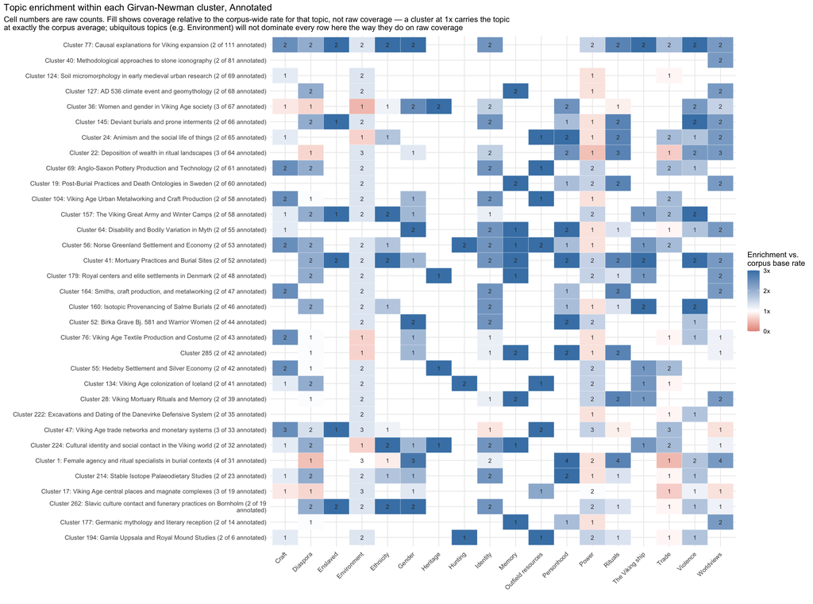

**Annotated, seed filtered**

Works with a cluster assignment and any topic coded: 369

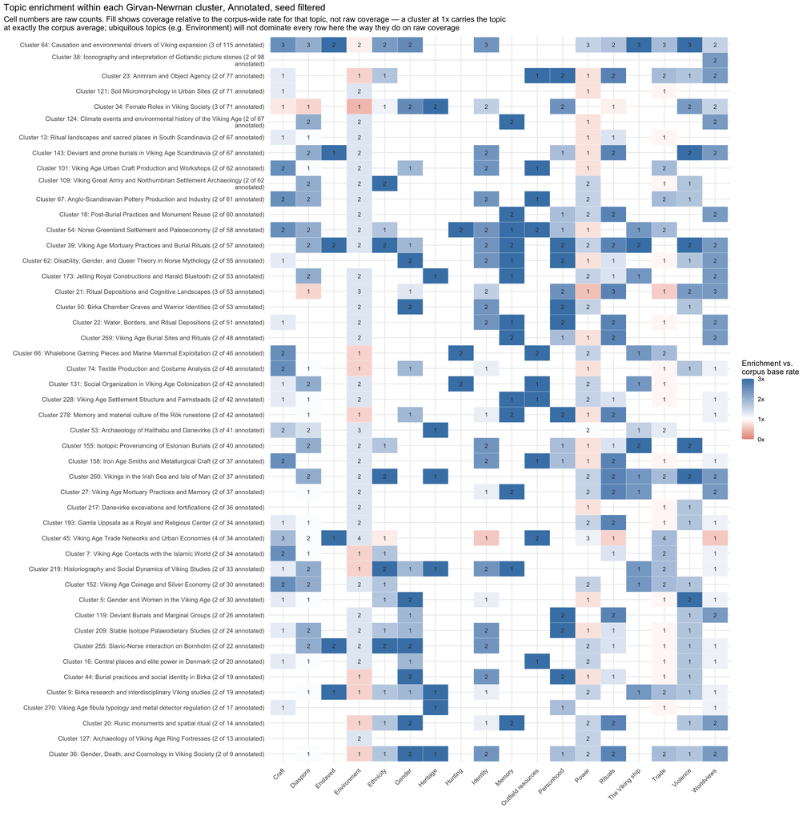

**Table, annotated**

The numbers behind the heatmap: one row per cluster and category, largest cluster first, strongest enrichment first within a cluster. A peak is a category whose Wilson 95% lower bound on the cluster’s share exceeds the corpus rate.

| Cluster | label | cluster size | annotated works | category | works with it | share (%) | corpus rate (%) | enrichment | Wilson 95% lower bound (%) | peak |
| --- | --- | --- | --- | --- | --- | --- | --- | --- | --- | --- |
| 77 | Causal explanations for Viking expansion | 111 | 2 | Enslaved | 2 | 100.0 | 8.4 | 11.90 | 34.2 | peak |
| 77 | Causal explanations for Viking expansion | 111 | 2 | The Viking ship | 2 | 100.0 | 21.1 | 4.73 | 34.2 | peak |
| 77 | Causal explanations for Viking expansion | 111 | 2 | Gender | 2 | 100.0 | 26.3 | 3.80 | 34.2 | peak |
| 77 | Causal explanations for Viking expansion | 111 | 2 | Violence | 2 | 100.0 | 28.7 | 3.48 | 34.2 | peak |
| 77 | Causal explanations for Viking expansion | 111 | 2 | Ethnicity | 2 | 100.0 | 29.0 | 3.45 | 34.2 | peak |
| 77 | Causal explanations for Viking expansion | 111 | 2 | Rituals | 2 | 100.0 | 37.7 | 2.65 | 34.2 |  |
| 77 | Causal explanations for Viking expansion | 111 | 2 | Craft | 2 | 100.0 | 40.1 | 2.49 | 34.2 |  |
| 77 | Causal explanations for Viking expansion | 111 | 2 | Identity | 2 | 100.0 | 41.7 | 2.40 | 34.2 |  |
| 77 | Causal explanations for Viking expansion | 111 | 2 | Worldviews | 2 | 100.0 | 43.1 | 2.32 | 34.2 |  |
| 77 | Causal explanations for Viking expansion | 111 | 2 | Diaspora | 2 | 100.0 | 48.5 | 2.06 | 34.2 |  |
| 77 | Causal explanations for Viking expansion | 111 | 2 | Trade | 2 | 100.0 | 53.9 | 1.85 | 34.2 |  |
| 77 | Causal explanations for Viking expansion | 111 | 2 | Power | 2 | 100.0 | 64.8 | 1.54 | 34.2 |  |
| 77 | Causal explanations for Viking expansion | 111 | 2 | Environment | 2 | 100.0 | 75.6 | 1.32 | 34.2 |  |
| 40 | Methodological approaches to stone iconography | 81 | 2 | Worldviews | 2 | 100.0 | 43.1 | 2.32 | 34.2 |  |
| 124 | Soil micromorphology in early medieval urban research | 69 | 2 | Environment | 2 | 100.0 | 75.6 | 1.32 | 34.2 |  |
| 124 | Soil micromorphology in early medieval urban research | 69 | 2 | Craft | 1 | 50.0 | 40.1 | 1.25 | 9.5 |  |
| 124 | Soil micromorphology in early medieval urban research | 69 | 2 | Trade | 1 | 50.0 | 53.9 | 0.93 | 9.5 |  |
| 124 | Soil micromorphology in early medieval urban research | 69 | 2 | Power | 1 | 50.0 | 64.8 | 0.77 | 9.5 |  |
| 127 | AD 536 climate event and geomythology | 68 | 2 | Memory | 2 | 100.0 | 16.0 | 6.25 | 34.2 | peak |
| 127 | AD 536 climate event and geomythology | 68 | 2 | Worldviews | 2 | 100.0 | 43.1 | 2.32 | 34.2 |  |
| 127 | AD 536 climate event and geomythology | 68 | 2 | Diaspora | 2 | 100.0 | 48.5 | 2.06 | 34.2 |  |
| 127 | AD 536 climate event and geomythology | 68 | 2 | Environment | 2 | 100.0 | 75.6 | 1.32 | 34.2 |  |
| 127 | AD 536 climate event and geomythology | 68 | 2 | Power | 1 | 50.0 | 64.8 | 0.77 | 9.5 |  |
| 36 | Women and gender in Viking Age society | 67 | 3 | Heritage | 2 | 66.7 | 6.5 | 10.25 | 20.8 | peak |
| 36 | Women and gender in Viking Age society | 67 | 3 | Gender | 2 | 66.7 | 26.3 | 2.54 | 20.8 |  |
| 36 | Women and gender in Viking Age society | 67 | 3 | Personhood | 2 | 66.7 | 27.4 | 2.44 | 20.8 |  |
| 36 | Women and gender in Viking Age society | 67 | 3 | Violence | 2 | 66.7 | 28.7 | 2.32 | 20.8 |  |
| 36 | Women and gender in Viking Age society | 67 | 3 | Identity | 2 | 66.7 | 41.7 | 1.60 | 20.8 |  |
| 36 | Women and gender in Viking Age society | 67 | 3 | Worldviews | 2 | 66.7 | 43.1 | 1.55 | 20.8 |  |
| 36 | Women and gender in Viking Age society | 67 | 3 | Ethnicity | 1 | 33.3 | 29.0 | 1.15 | 6.1 |  |

[output cut: 252 more lines]

**Table, seed filtered**

Same columns, for the seed-filtered run.

| Cluster | label | cluster size | annotated works | category | works with it | share (%) | corpus rate (%) | enrichment | Wilson 95% lower bound (%) | peak |
| --- | --- | --- | --- | --- | --- | --- | --- | --- | --- | --- |
| 64 | Causation and environmental drivers of Viking expansion | 115 | 3 | Enslaved | 2 | 66.7 | 8.4 | 7.94 | 20.8 | peak |
| 64 | Causation and environmental drivers of Viking expansion | 115 | 3 | The Viking ship | 3 | 100.0 | 21.1 | 4.73 | 43.9 | peak |
| 64 | Causation and environmental drivers of Viking expansion | 115 | 3 | Violence | 3 | 100.0 | 28.7 | 3.48 | 43.9 | peak |
| 64 | Causation and environmental drivers of Viking expansion | 115 | 3 | Gender | 2 | 66.7 | 26.3 | 2.54 | 20.8 |  |
| 64 | Causation and environmental drivers of Viking expansion | 115 | 3 | Craft | 3 | 100.0 | 40.1 | 2.49 | 43.9 | peak |
| 64 | Causation and environmental drivers of Viking expansion | 115 | 3 | Identity | 3 | 100.0 | 41.7 | 2.40 | 43.9 | peak |
| 64 | Causation and environmental drivers of Viking expansion | 115 | 3 | Ethnicity | 2 | 66.7 | 29.0 | 2.30 | 20.8 |  |
| 64 | Causation and environmental drivers of Viking expansion | 115 | 3 | Diaspora | 3 | 100.0 | 48.5 | 2.06 | 43.9 |  |
| 64 | Causation and environmental drivers of Viking expansion | 115 | 3 | Trade | 3 | 100.0 | 53.9 | 1.85 | 43.9 |  |
| 64 | Causation and environmental drivers of Viking expansion | 115 | 3 | Rituals | 2 | 66.7 | 37.7 | 1.77 | 20.8 |  |
| 64 | Causation and environmental drivers of Viking expansion | 115 | 3 | Worldviews | 2 | 66.7 | 43.1 | 1.55 | 20.8 |  |
| 64 | Causation and environmental drivers of Viking expansion | 115 | 3 | Power | 3 | 100.0 | 64.8 | 1.54 | 43.9 |  |
| 64 | Causation and environmental drivers of Viking expansion | 115 | 3 | Environment | 2 | 66.7 | 75.6 | 0.88 | 20.8 |  |
| 38 | Iconography and interpretation of Gotlandic picture stones | 98 | 2 | Worldviews | 2 | 100.0 | 43.1 | 2.32 | 34.2 |  |
| 23 | Animism and Object Agency | 77 | 2 | Personhood | 2 | 100.0 | 27.4 | 3.65 | 34.2 | peak |
| 23 | Animism and Object Agency | 77 | 2 | Outfield resources | 1 | 50.0 | 15.7 | 3.18 | 9.5 |  |
| 23 | Animism and Object Agency | 77 | 2 | Rituals | 2 | 100.0 | 37.7 | 2.65 | 34.2 |  |
| 23 | Animism and Object Agency | 77 | 2 | Worldviews | 2 | 100.0 | 43.1 | 2.32 | 34.2 |  |
| 23 | Animism and Object Agency | 77 | 2 | Trade | 2 | 100.0 | 53.9 | 1.85 | 34.2 |  |
| 23 | Animism and Object Agency | 77 | 2 | Violence | 1 | 50.0 | 28.7 | 1.74 | 9.5 |  |
| 23 | Animism and Object Agency | 77 | 2 | Ethnicity | 1 | 50.0 | 29.0 | 1.72 | 9.5 |  |
| 23 | Animism and Object Agency | 77 | 2 | Craft | 1 | 50.0 | 40.1 | 1.25 | 9.5 |  |
| 23 | Animism and Object Agency | 77 | 2 | Power | 1 | 50.0 | 64.8 | 0.77 | 9.5 |  |
| 23 | Animism and Object Agency | 77 | 2 | Environment | 1 | 50.0 | 75.6 | 0.66 | 9.5 |  |
| 121 | Soil Micromorphology in Urban Sites | 71 | 2 | Environment | 2 | 100.0 | 75.6 | 1.32 | 34.2 |  |
| 121 | Soil Micromorphology in Urban Sites | 71 | 2 | Craft | 1 | 50.0 | 40.1 | 1.25 | 9.5 |  |
| 121 | Soil Micromorphology in Urban Sites | 71 | 2 | Trade | 1 | 50.0 | 53.9 | 0.93 | 9.5 |  |
| 121 | Soil Micromorphology in Urban Sites | 71 | 2 | Power | 1 | 50.0 | 64.8 | 0.77 | 9.5 |  |
| 34 | Female Roles in Viking Society | 71 | 3 | Heritage | 2 | 66.7 | 6.5 | 10.25 | 20.8 | peak |
| 34 | Female Roles in Viking Society | 71 | 3 | Gender | 2 | 66.7 | 26.3 | 2.54 | 20.8 |  |

[output cut: 358 more lines]

### By method

Same approach as the topic comparison above, applied to method.

**Annotated**

Works with a cluster assignment and any method coded: 368

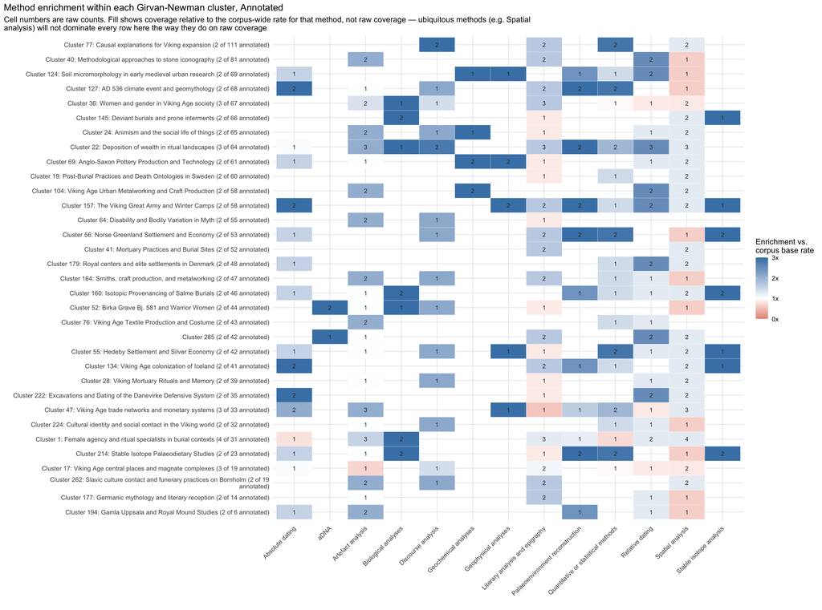

**Annotated, seed filtered**

Works with a cluster assignment and any method coded: 368

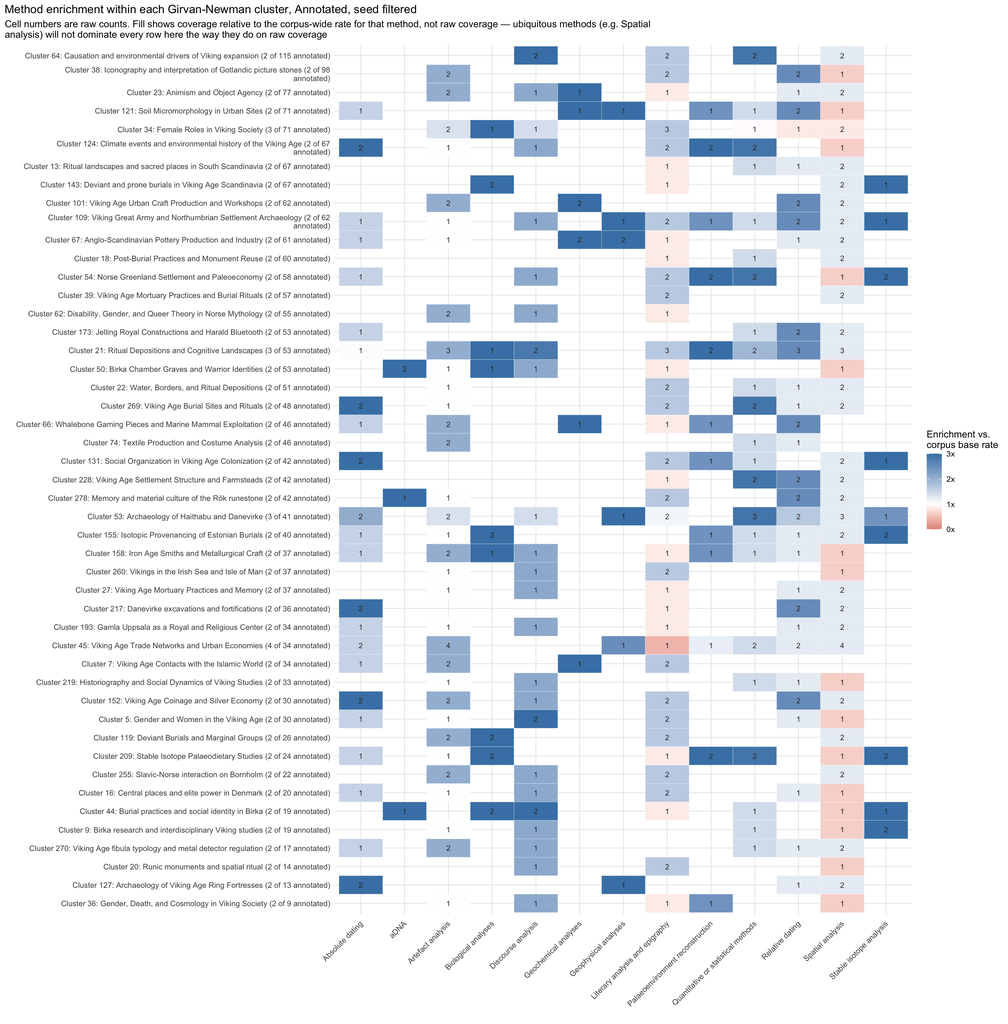

**Table, annotated**

The numbers behind the heatmap: one row per cluster and category, largest cluster first, strongest enrichment first within a cluster. A peak is a category whose Wilson 95% lower bound on the cluster’s share exceeds the corpus rate.

| Cluster | label | cluster size | annotated works | category | works with it | share (%) | corpus rate (%) | enrichment | Wilson 95% lower bound (%) | peak |
| --- | --- | --- | --- | --- | --- | --- | --- | --- | --- | --- |
| 77 | Causal explanations for Viking expansion | 111 | 2 | Discourse analysis | 2 | 100.0 | 23.6 | 4.23 | 34.2 | peak |
| 77 | Causal explanations for Viking expansion | 111 | 2 | Quantitative or statistical methods | 2 | 100.0 | 34.8 | 2.88 | 34.2 |  |
| 77 | Causal explanations for Viking expansion | 111 | 2 | Literary analysis and epigraphy | 2 | 100.0 | 59.8 | 1.67 | 34.2 |  |
| 77 | Causal explanations for Viking expansion | 111 | 2 | Spatial analysis | 2 | 100.0 | 79.3 | 1.26 | 34.2 |  |
| 40 | Methodological approaches to stone iconography | 81 | 2 | Relative dating | 2 | 100.0 | 39.7 | 2.52 | 34.2 |  |
| 40 | Methodological approaches to stone iconography | 81 | 2 | Artefact analysis | 2 | 100.0 | 48.9 | 2.04 | 34.2 |  |
| 40 | Methodological approaches to stone iconography | 81 | 2 | Literary analysis and epigraphy | 2 | 100.0 | 59.8 | 1.67 | 34.2 |  |
| 40 | Methodological approaches to stone iconography | 81 | 2 | Spatial analysis | 1 | 50.0 | 79.3 | 0.63 | 9.5 |  |
| 124 | Soil micromorphology in early medieval urban research | 69 | 2 | Geochemical analyses | 1 | 50.0 | 6.0 | 8.36 | 9.5 | peak |
| 124 | Soil micromorphology in early medieval urban research | 69 | 2 | Geophysical analyses | 1 | 50.0 | 10.1 | 4.97 | 9.5 |  |
| 124 | Soil micromorphology in early medieval urban research | 69 | 2 | Relative dating | 2 | 100.0 | 39.7 | 2.52 | 34.2 |  |
| 124 | Soil micromorphology in early medieval urban research | 69 | 2 | Palaeoenvironment reconstruction | 1 | 50.0 | 20.7 | 2.42 | 9.5 |  |
| 124 | Soil micromorphology in early medieval urban research | 69 | 2 | Absolute dating | 1 | 50.0 | 32.3 | 1.55 | 9.5 |  |
| 124 | Soil micromorphology in early medieval urban research | 69 | 2 | Quantitative or statistical methods | 1 | 50.0 | 34.8 | 1.44 | 9.5 |  |
| 124 | Soil micromorphology in early medieval urban research | 69 | 2 | Spatial analysis | 1 | 50.0 | 79.3 | 0.63 | 9.5 |  |
| 127 | AD 536 climate event and geomythology | 68 | 2 | Palaeoenvironment reconstruction | 2 | 100.0 | 20.7 | 4.84 | 34.2 | peak |
| 127 | AD 536 climate event and geomythology | 68 | 2 | Absolute dating | 2 | 100.0 | 32.3 | 3.09 | 34.2 | peak |
| 127 | AD 536 climate event and geomythology | 68 | 2 | Quantitative or statistical methods | 2 | 100.0 | 34.8 | 2.88 | 34.2 |  |
| 127 | AD 536 climate event and geomythology | 68 | 2 | Discourse analysis | 1 | 50.0 | 23.6 | 2.11 | 9.5 |  |
| 127 | AD 536 climate event and geomythology | 68 | 2 | Literary analysis and epigraphy | 2 | 100.0 | 59.8 | 1.67 | 34.2 |  |
| 127 | AD 536 climate event and geomythology | 68 | 2 | Artefact analysis | 1 | 50.0 | 48.9 | 1.02 | 9.5 |  |
| 127 | AD 536 climate event and geomythology | 68 | 2 | Spatial analysis | 1 | 50.0 | 79.3 | 0.63 | 9.5 |  |
| 36 | Women and gender in Viking Age society | 67 | 3 | Biological analyses | 1 | 33.3 | 10.9 | 3.07 | 6.1 |  |
| 36 | Women and gender in Viking Age society | 67 | 3 | Literary analysis and epigraphy | 3 | 100.0 | 59.8 | 1.67 | 43.9 |  |
| 36 | Women and gender in Viking Age society | 67 | 3 | Discourse analysis | 1 | 33.3 | 23.6 | 1.41 | 6.1 |  |
| 36 | Women and gender in Viking Age society | 67 | 3 | Artefact analysis | 2 | 66.7 | 48.9 | 1.36 | 20.8 |  |
| 36 | Women and gender in Viking Age society | 67 | 3 | Quantitative or statistical methods | 1 | 33.3 | 34.8 | 0.96 | 6.1 |  |
| 36 | Women and gender in Viking Age society | 67 | 3 | Relative dating | 1 | 33.3 | 39.7 | 0.84 | 6.1 |  |
| 36 | Women and gender in Viking Age society | 67 | 3 | Spatial analysis | 2 | 66.7 | 79.3 | 0.84 | 20.8 |  |
| 145 | Deviant burials and prone interments | 66 | 2 | Biological analyses | 2 | 100.0 | 10.9 | 9.20 | 34.2 | peak |

[output cut: 157 more lines]

**Table, seed filtered**

Same columns, for the seed-filtered run.

| Cluster | label | cluster size | annotated works | category | works with it | share (%) | corpus rate (%) | enrichment | Wilson 95% lower bound (%) | peak |
| --- | --- | --- | --- | --- | --- | --- | --- | --- | --- | --- |
| 64 | Causation and environmental drivers of Viking expansion | 115 | 2 | Discourse analysis | 2 | 100.0 | 23.6 | 4.23 | 34.2 | peak |
| 64 | Causation and environmental drivers of Viking expansion | 115 | 2 | Quantitative or statistical methods | 2 | 100.0 | 34.8 | 2.88 | 34.2 |  |
| 64 | Causation and environmental drivers of Viking expansion | 115 | 2 | Literary analysis and epigraphy | 2 | 100.0 | 59.8 | 1.67 | 34.2 |  |
| 64 | Causation and environmental drivers of Viking expansion | 115 | 2 | Spatial analysis | 2 | 100.0 | 79.3 | 1.26 | 34.2 |  |
| 38 | Iconography and interpretation of Gotlandic picture stones | 98 | 2 | Relative dating | 2 | 100.0 | 39.7 | 2.52 | 34.2 |  |
| 38 | Iconography and interpretation of Gotlandic picture stones | 98 | 2 | Artefact analysis | 2 | 100.0 | 48.9 | 2.04 | 34.2 |  |
| 38 | Iconography and interpretation of Gotlandic picture stones | 98 | 2 | Literary analysis and epigraphy | 2 | 100.0 | 59.8 | 1.67 | 34.2 |  |
| 38 | Iconography and interpretation of Gotlandic picture stones | 98 | 2 | Spatial analysis | 1 | 50.0 | 79.3 | 0.63 | 9.5 |  |
| 23 | Animism and Object Agency | 77 | 2 | Geochemical analyses | 1 | 50.0 | 6.0 | 8.36 | 9.5 | peak |
| 23 | Animism and Object Agency | 77 | 2 | Discourse analysis | 1 | 50.0 | 23.6 | 2.11 | 9.5 |  |
| 23 | Animism and Object Agency | 77 | 2 | Artefact analysis | 2 | 100.0 | 48.9 | 2.04 | 34.2 |  |
| 23 | Animism and Object Agency | 77 | 2 | Relative dating | 1 | 50.0 | 39.7 | 1.26 | 9.5 |  |
| 23 | Animism and Object Agency | 77 | 2 | Spatial analysis | 2 | 100.0 | 79.3 | 1.26 | 34.2 |  |
| 23 | Animism and Object Agency | 77 | 2 | Literary analysis and epigraphy | 1 | 50.0 | 59.8 | 0.84 | 9.5 |  |
| 121 | Soil Micromorphology in Urban Sites | 71 | 2 | Geochemical analyses | 1 | 50.0 | 6.0 | 8.36 | 9.5 | peak |
| 121 | Soil Micromorphology in Urban Sites | 71 | 2 | Geophysical analyses | 1 | 50.0 | 10.1 | 4.97 | 9.5 |  |
| 121 | Soil Micromorphology in Urban Sites | 71 | 2 | Relative dating | 2 | 100.0 | 39.7 | 2.52 | 34.2 |  |
| 121 | Soil Micromorphology in Urban Sites | 71 | 2 | Palaeoenvironment reconstruction | 1 | 50.0 | 20.7 | 2.42 | 9.5 |  |
| 121 | Soil Micromorphology in Urban Sites | 71 | 2 | Absolute dating | 1 | 50.0 | 32.3 | 1.55 | 9.5 |  |
| 121 | Soil Micromorphology in Urban Sites | 71 | 2 | Quantitative or statistical methods | 1 | 50.0 | 34.8 | 1.44 | 9.5 |  |
| 121 | Soil Micromorphology in Urban Sites | 71 | 2 | Spatial analysis | 1 | 50.0 | 79.3 | 0.63 | 9.5 |  |
| 34 | Female Roles in Viking Society | 71 | 3 | Biological analyses | 1 | 33.3 | 10.9 | 3.07 | 6.1 |  |
| 34 | Female Roles in Viking Society | 71 | 3 | Literary analysis and epigraphy | 3 | 100.0 | 59.8 | 1.67 | 43.9 |  |
| 34 | Female Roles in Viking Society | 71 | 3 | Discourse analysis | 1 | 33.3 | 23.6 | 1.41 | 6.1 |  |
| 34 | Female Roles in Viking Society | 71 | 3 | Artefact analysis | 2 | 66.7 | 48.9 | 1.36 | 20.8 |  |
| 34 | Female Roles in Viking Society | 71 | 3 | Quantitative or statistical methods | 1 | 33.3 | 34.8 | 0.96 | 6.1 |  |
| 34 | Female Roles in Viking Society | 71 | 3 | Relative dating | 1 | 33.3 | 39.7 | 0.84 | 6.1 |  |
| 34 | Female Roles in Viking Society | 71 | 3 | Spatial analysis | 2 | 66.7 | 79.3 | 0.84 | 20.8 |  |
| 124 | Climate events and environmental history of the Viking Age | 67 | 2 | Palaeoenvironment reconstruction | 2 | 100.0 | 20.7 | 4.84 | 34.2 | peak |
| 124 | Climate events and environmental history of the Viking Age | 67 | 2 | Absolute dating | 2 | 100.0 | 32.3 | 3.09 | 34.2 | peak |

[output cut: 229 more lines]

### By source of evidence

Same approach again, applied to source of evidence.

**Annotated**

Works with a cluster assignment and any source coded: 368

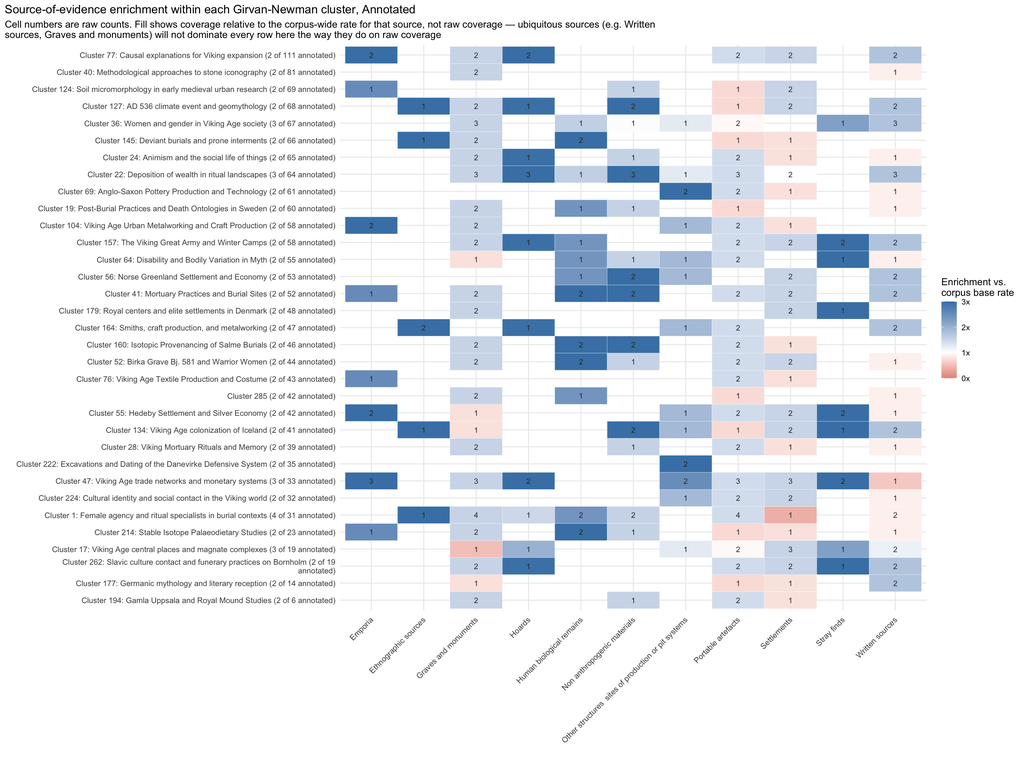

**Annotated, seed filtered**

Works with a cluster assignment and any source coded: 368

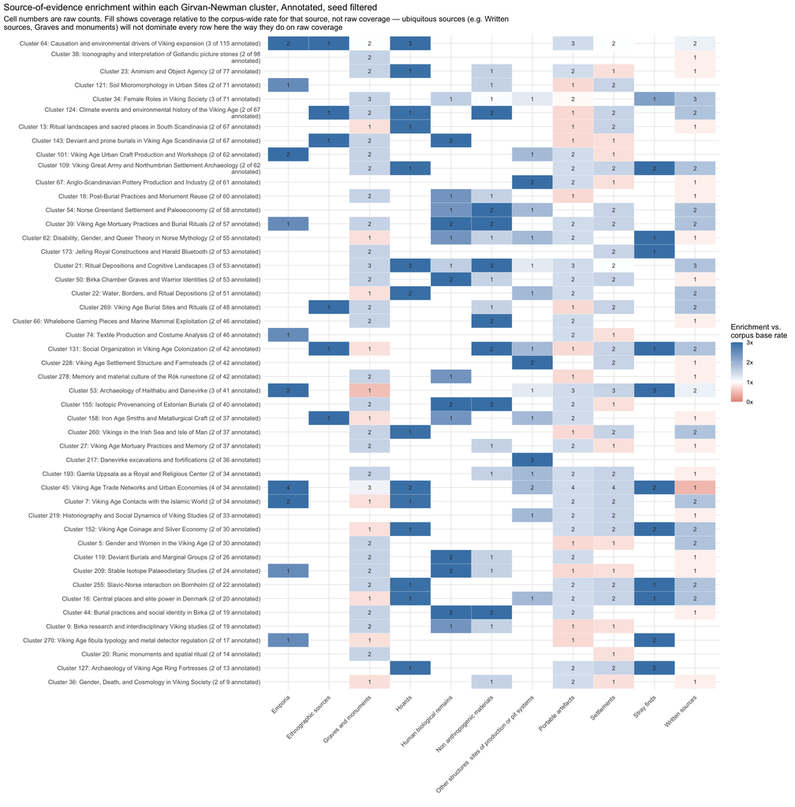

**Table, annotated**

The numbers behind the heatmap: one row per cluster and category, largest cluster first, strongest enrichment first within a cluster. A peak is a category whose Wilson 95% lower bound on the cluster’s share exceeds the corpus rate.

| Cluster | label | cluster size | annotated works | category | works with it | share (%) | corpus rate (%) | enrichment | Wilson 95% lower bound (%) | peak |
| --- | --- | --- | --- | --- | --- | --- | --- | --- | --- | --- |
| 77 | Causal explanations for Viking expansion | 111 | 2 | Hoards | 2 | 100.0 | 16.8 | 5.94 | 34.2 | peak |
| 77 | Causal explanations for Viking expansion | 111 | 2 | Emporia | 2 | 100.0 | 19.8 | 5.04 | 34.2 | peak |
| 77 | Causal explanations for Viking expansion | 111 | 2 | Written sources | 2 | 100.0 | 57.1 | 1.75 | 34.2 |  |
| 77 | Causal explanations for Viking expansion | 111 | 2 | Graves and monuments | 2 | 100.0 | 65.2 | 1.53 | 34.2 |  |
| 77 | Causal explanations for Viking expansion | 111 | 2 | Settlements | 2 | 100.0 | 65.5 | 1.53 | 34.2 |  |
| 77 | Causal explanations for Viking expansion | 111 | 2 | Portable artefacts | 2 | 100.0 | 69.8 | 1.43 | 34.2 |  |
| 40 | Methodological approaches to stone iconography | 81 | 2 | Graves and monuments | 2 | 100.0 | 65.2 | 1.53 | 34.2 |  |
| 40 | Methodological approaches to stone iconography | 81 | 2 | Written sources | 1 | 50.0 | 57.1 | 0.88 | 9.5 |  |
| 124 | Soil micromorphology in early medieval urban research | 69 | 2 | Emporia | 1 | 50.0 | 19.8 | 2.52 | 9.5 |  |
| 124 | Soil micromorphology in early medieval urban research | 69 | 2 | Non anthropogenic materials | 1 | 50.0 | 32.3 | 1.55 | 9.5 |  |
| 124 | Soil micromorphology in early medieval urban research | 69 | 2 | Settlements | 2 | 100.0 | 65.5 | 1.53 | 34.2 |  |
| 124 | Soil micromorphology in early medieval urban research | 69 | 2 | Portable artefacts | 1 | 50.0 | 69.8 | 0.72 | 9.5 |  |
| 127 | AD 536 climate event and geomythology | 68 | 2 | Ethnographic sources | 1 | 50.0 | 6.5 | 7.67 | 9.5 | peak |
| 127 | AD 536 climate event and geomythology | 68 | 2 | Non anthropogenic materials | 2 | 100.0 | 32.3 | 3.09 | 34.2 | peak |
| 127 | AD 536 climate event and geomythology | 68 | 2 | Hoards | 1 | 50.0 | 16.8 | 2.97 | 9.5 |  |
| 127 | AD 536 climate event and geomythology | 68 | 2 | Written sources | 2 | 100.0 | 57.1 | 1.75 | 34.2 |  |
| 127 | AD 536 climate event and geomythology | 68 | 2 | Graves and monuments | 2 | 100.0 | 65.2 | 1.53 | 34.2 |  |
| 127 | AD 536 climate event and geomythology | 68 | 2 | Settlements | 2 | 100.0 | 65.5 | 1.53 | 34.2 |  |
| 127 | AD 536 climate event and geomythology | 68 | 2 | Portable artefacts | 1 | 50.0 | 69.8 | 0.72 | 9.5 |  |
| 36 | Women and gender in Viking Age society | 67 | 3 | Stray finds | 1 | 33.3 | 14.9 | 2.23 | 6.1 |  |
| 36 | Women and gender in Viking Age society | 67 | 3 | Written sources | 3 | 100.0 | 57.1 | 1.75 | 43.9 |  |
| 36 | Women and gender in Viking Age society | 67 | 3 | Human biological remains | 1 | 33.3 | 20.9 | 1.59 | 6.1 |  |
| 36 | Women and gender in Viking Age society | 67 | 3 | Graves and monuments | 3 | 100.0 | 65.2 | 1.53 | 43.9 |  |
| 36 | Women and gender in Viking Age society | 67 | 3 | Other structures sites of production or pit systems | 1 | 33.3 | 26.6 | 1.25 | 6.1 |  |
| 36 | Women and gender in Viking Age society | 67 | 3 | Non anthropogenic materials | 1 | 33.3 | 32.3 | 1.03 | 6.1 |  |
| 36 | Women and gender in Viking Age society | 67 | 3 | Portable artefacts | 2 | 66.7 | 69.8 | 0.95 | 20.8 |  |
| 145 | Deviant burials and prone interments | 66 | 2 | Ethnographic sources | 1 | 50.0 | 6.5 | 7.67 | 9.5 | peak |
| 145 | Deviant burials and prone interments | 66 | 2 | Human biological remains | 2 | 100.0 | 20.9 | 4.78 | 34.2 | peak |
| 145 | Deviant burials and prone interments | 66 | 2 | Graves and monuments | 2 | 100.0 | 65.2 | 1.53 | 34.2 |  |
| 145 | Deviant burials and prone interments | 66 | 2 | Settlements | 1 | 50.0 | 65.5 | 0.76 | 9.5 |  |

[output cut: 150 more lines]

**Table, seed filtered**

Same columns, for the seed-filtered run.

| Cluster | label | cluster size | annotated works | category | works with it | share (%) | corpus rate (%) | enrichment | Wilson 95% lower bound (%) | peak |
| --- | --- | --- | --- | --- | --- | --- | --- | --- | --- | --- |
| 64 | Causation and environmental drivers of Viking expansion | 115 | 3 | Hoards | 3 | 100.0 | 16.8 | 5.94 | 43.9 | peak |
| 64 | Causation and environmental drivers of Viking expansion | 115 | 3 | Ethnographic sources | 1 | 33.3 | 6.5 | 5.11 | 6.1 |  |
| 64 | Causation and environmental drivers of Viking expansion | 115 | 3 | Emporia | 2 | 66.7 | 19.8 | 3.36 | 20.8 | peak |
| 64 | Causation and environmental drivers of Viking expansion | 115 | 3 | Portable artefacts | 3 | 100.0 | 69.8 | 1.43 | 43.9 |  |
| 64 | Causation and environmental drivers of Viking expansion | 115 | 3 | Written sources | 2 | 66.7 | 57.1 | 1.17 | 20.8 |  |
| 64 | Causation and environmental drivers of Viking expansion | 115 | 3 | Graves and monuments | 2 | 66.7 | 65.2 | 1.02 | 20.8 |  |
| 64 | Causation and environmental drivers of Viking expansion | 115 | 3 | Settlements | 2 | 66.7 | 65.5 | 1.02 | 20.8 |  |
| 38 | Iconography and interpretation of Gotlandic picture stones | 98 | 2 | Graves and monuments | 2 | 100.0 | 65.2 | 1.53 | 34.2 |  |
| 38 | Iconography and interpretation of Gotlandic picture stones | 98 | 2 | Written sources | 1 | 50.0 | 57.1 | 0.88 | 9.5 |  |
| 23 | Animism and Object Agency | 77 | 2 | Hoards | 1 | 50.0 | 16.8 | 2.97 | 9.5 |  |
| 23 | Animism and Object Agency | 77 | 2 | Non anthropogenic materials | 1 | 50.0 | 32.3 | 1.55 | 9.5 |  |
| 23 | Animism and Object Agency | 77 | 2 | Graves and monuments | 2 | 100.0 | 65.2 | 1.53 | 34.2 |  |
| 23 | Animism and Object Agency | 77 | 2 | Portable artefacts | 2 | 100.0 | 69.8 | 1.43 | 34.2 |  |
| 23 | Animism and Object Agency | 77 | 2 | Written sources | 1 | 50.0 | 57.1 | 0.88 | 9.5 |  |
| 23 | Animism and Object Agency | 77 | 2 | Settlements | 1 | 50.0 | 65.5 | 0.76 | 9.5 |  |
| 121 | Soil Micromorphology in Urban Sites | 71 | 2 | Emporia | 1 | 50.0 | 19.8 | 2.52 | 9.5 |  |
| 121 | Soil Micromorphology in Urban Sites | 71 | 2 | Non anthropogenic materials | 1 | 50.0 | 32.3 | 1.55 | 9.5 |  |
| 121 | Soil Micromorphology in Urban Sites | 71 | 2 | Settlements | 2 | 100.0 | 65.5 | 1.53 | 34.2 |  |
| 121 | Soil Micromorphology in Urban Sites | 71 | 2 | Portable artefacts | 1 | 50.0 | 69.8 | 0.72 | 9.5 |  |
| 34 | Female Roles in Viking Society | 71 | 3 | Stray finds | 1 | 33.3 | 14.9 | 2.23 | 6.1 |  |
| 34 | Female Roles in Viking Society | 71 | 3 | Written sources | 3 | 100.0 | 57.1 | 1.75 | 43.9 |  |
| 34 | Female Roles in Viking Society | 71 | 3 | Human biological remains | 1 | 33.3 | 20.9 | 1.59 | 6.1 |  |
| 34 | Female Roles in Viking Society | 71 | 3 | Graves and monuments | 3 | 100.0 | 65.2 | 1.53 | 43.9 |  |
| 34 | Female Roles in Viking Society | 71 | 3 | Other structures sites of production or pit systems | 1 | 33.3 | 26.6 | 1.25 | 6.1 |  |
| 34 | Female Roles in Viking Society | 71 | 3 | Non anthropogenic materials | 1 | 33.3 | 32.3 | 1.03 | 6.1 |  |
| 34 | Female Roles in Viking Society | 71 | 3 | Portable artefacts | 2 | 66.7 | 69.8 | 0.95 | 20.8 |  |
| 124 | Climate events and environmental history of the Viking Age | 67 | 2 | Ethnographic sources | 1 | 50.0 | 6.5 | 7.67 | 9.5 | peak |
| 124 | Climate events and environmental history of the Viking Age | 67 | 2 | Non anthropogenic materials | 2 | 100.0 | 32.3 | 3.09 | 34.2 | peak |
| 124 | Climate events and environmental history of the Viking Age | 67 | 2 | Hoards | 1 | 50.0 | 16.8 | 2.97 | 9.5 |  |
| 124 | Climate events and environmental history of the Viking Age | 67 | 2 | Written sources | 2 | 100.0 | 57.1 | 1.75 | 34.2 |  |

[output cut: 215 more lines]

## Cluster signatures: peak count and peak strength

Throughout this section, “cluster” means a Girvan-Newman graph cluster (`community_gn`), not a scholarly or social cluster.

The topic, method, and source enrichment findings above surface individual standout cells one at a time. This section combines them into two directly interpretable numbers per cluster, so the clusters most worth a closer look surface first instead of requiring a manual scan across three separate tables.

A **peak** is any category (topic, method, or source) whose 95% Wilson confidence interval on a cluster’s coverage rate lies entirely above the corpus-wide rate for that category — meaning the cluster’s coverage is higher than baseline with reasonable statistical confidence, not just a higher raw count. This adapts to sample size automatically: a cluster with only 3 annotated works needs a much larger raw enrichment to register as a peak than a cluster with 13, because a small sample’s interval is wider. This is the same criterion used in the topic, method, and source findings above (`ci_lower > corpus_rate`); “peak” here just names a category that already met that bar, so this section’s peak count and mean enrichment are computed directly from the same standouts listed there, not a separate pass.

For each cluster, two numbers: how many peaks it has, and how strong those peaks are on average. Neither is combined into a single score — peak count times mean enrichment is not a real, interpretable unit, and collapsing two different kinds of signal into one number invites over-reading it. Plotted directly instead: clusters with many peaks AND high average enrichment are worth reading first; a cluster with one very large but isolated peak is a different kind of finding (a strong single signal) than one with several moderate peaks (a broader, possibly more coherent pattern) — the plot keeps that distinction visible rather than flattening it. Whether a cluster’s peak categories actually cohere thematically is a judgment that requires reading them against domain knowledge of this corpus, which this plot does not attempt.

### Peak count against peak strength

**Annotated**

Peaks found (Wilson lower bound exceeds corpus baseline): 101

[figure not shown]

**Annotated, seed filtered**

Peaks found (Wilson lower bound exceeds corpus baseline): 130

[figure not shown]

**Table, annotated**

The plot’s points, one row per cluster with at least one peak, most peaks first.

| Cluster | label | peaks | mean enrichment | peak categories (enrichment) |
| --- | --- | --- | --- | --- |
| 77 | Causal explanations for Viking expansion | 8 | 5.32 | topic: Enslaved (11.9x); topic: Ethnicity (3.4x); topic: Gender (3.8x); topic: The Viking ship (4.7x); topic: Violence (3.5x); method: Discourse analysis (4.2x); source: Emporia (5x); source: Hoards (… |
| 41 | Mortuary Practices and Burial Sites | 8 | 5.17 | topic: Enslaved (11.9x); topic: Ethnicity (3.4x); topic: Memory (6.3x); topic: Personhood (3.7x); topic: The Viking ship (4.7x); topic: Violence (3.5x); source: Human biological remains (4.8x); source… |
| 157 | The Viking Great Army and Winter Camps | 7 | 5.35 | topic: Enslaved (6x); topic: Ethnicity (3.4x); topic: Violence (3.5x); method: Absolute dating (3.1x); method: Geophysical analyses (9.9x); method: Palaeoenvironment reconstruction (4.8x); source: Str… |
| 160 | Isotopic Provenancing of Salme Burials | 6 | 5.42 | topic: The Viking ship (4.7x); topic: Violence (3.5x); method: Biological analyses (9.2x); method: Stable isotope analysis (7.2x); source: Human biological remains (4.8x); source: Non anthropogenic ma… |
| 22 | Deposition of wealth in ritual landscapes | 6 | 3.29 | topic: Rituals (2.7x); topic: Worldviews (2.3x); method: Palaeoenvironment reconstruction (3.2x); method: Relative dating (2.5x); source: Hoards (5.9x); source: Non anthropogenic materials (3.1x) |
| 145 | Deviant burials and prone interments | 5 | 6.22 | topic: Enslaved (6x); topic: Violence (3.5x); method: Biological analyses (9.2x); source: Ethnographic sources (7.7x); source: Human biological remains (4.8x) |
| 56 | Norse Greenland Settlement and Economy | 5 | 6.19 | topic: Hunting (9.5x); topic: Outfield resources (6.4x); method: Palaeoenvironment reconstruction (4.8x); method: Stable isotope analysis (7.2x); source: Non anthropogenic materials (3.1x) |
| 214 | Stable Isotope Palaeodietary Studies | 5 | 5.94 | topic: Personhood (3.7x); method: Biological analyses (9.2x); method: Palaeoenvironment reconstruction (4.8x); method: Stable isotope analysis (7.2x); source: Human biological remains (4.8x) |
| 127 | AD 536 climate event and geomythology | 5 | 4.99 | topic: Memory (6.3x); method: Absolute dating (3.1x); method: Palaeoenvironment reconstruction (4.8x); source: Ethnographic sources (7.7x); source: Non anthropogenic materials (3.1x) |
| 47 | Viking Age trade networks and monetary systems | 5 | 4.04 | topic: Craft (2.5x); topic: Outfield resources (4.2x); source: Emporia (5x); source: Hoards (4x); source: Stray finds (4.5x) |
| 1 | Female agency and ritual specialists in burial contexts | 5 | 3.22 | topic: Gender (2.9x); topic: Personhood (3.7x); topic: Rituals (2.7x); topic: Worldviews (2.3x); method: Biological analyses (4.6x) |
| 52 | Birka Grave Bj. 581 and Warrior Women | 4 | 8.81 | topic: Gender (3.8x); topic: Personhood (3.7x); method: aDNA (23x); source: Human biological remains (4.8x) |
| 134 | Viking Age colonization of Iceland | 4 | 5.83 | topic: Hunting (9.5x); method: Absolute dating (3.1x); source: Ethnographic sources (7.7x); source: Non anthropogenic materials (3.1x) |
| 69 | Anglo-Saxon Pottery Production and Technology | 3 | 10.14 | method: Geochemical analyses (16.7x); method: Geophysical analyses (9.9x); source: Other structures sites of production or pit systems (3.8x) |
| 285 | NA | 3 | 7.14 | topic: Memory (6.3x); topic: Personhood (3.7x); method: aDNA (11.5x) |
| 55 | Hedeby Settlement and Silver Economy | 3 | 6.47 | topic: Heritage (7.7x); source: Emporia (5x); source: Stray finds (6.7x) |
| 262 | Slavic culture contact and funerary practices on Bornholm | 3 | 6.39 | topic: Enslaved (11.9x); topic: Ethnicity (3.4x); topic: Gender (3.8x) |
| 104 | Viking Age Urban Metalworking and Craft Production | 2 | 10.88 | method: Geochemical analyses (16.7x); source: Emporia (5x) |
| 24 | Animism and the social life of things | 2 | 6.01 | topic: Personhood (3.7x); method: Geochemical analyses (8.4x) |
| 224 | Cultural identity and social contact in the Viking world | 2 | 5.57 | topic: Ethnicity (3.4x); topic: Heritage (7.7x) |
| 64 | Disability and Bodily Variation in Myth | 2 | 3.73 | topic: Gender (3.8x); topic: Personhood (3.7x) |
| 222 | Excavations and Dating of the Danevirke Defensive System | 2 | 3.42 | method: Absolute dating (3.1x); source: Other structures sites of production or pit systems (3.8x) |
| 164 | Smiths, craft production, and metalworking | 1 | 15.33 | source: Ethnographic sources (15.3x) |
| 36 | Women and gender in Viking Age society | 1 | 10.25 | topic: Heritage (10.2x) |
| 124 | Soil micromorphology in early medieval urban research | 1 | 8.36 | method: Geochemical analyses (8.4x) |
| 179 | Royal centers and elite settlements in Denmark | 1 | 7.69 | topic: Heritage (7.7x) |
| 19 | Post-Burial Practices and Death Ontologies in Sweden | 1 | 6.25 | topic: Memory (6.3x) |
| 28 | Viking Mortuary Rituals and Memory | 1 | 6.25 | topic: Memory (6.3x) |

**Table, seed filtered**

Same columns, for the seed-filtered run.

| Cluster | label | peaks | mean enrichment | peak categories (enrichment) |
| --- | --- | --- | --- | --- |
| 39 | Viking Age Mortuary Practices and Burial Rituals | 8 | 5.17 | topic: Enslaved (11.9x); topic: Ethnicity (3.4x); topic: Memory (6.3x); topic: Personhood (3.7x); topic: The Viking ship (4.7x); topic: Violence (3.5x); source: Human biological remains (4.8x); source… |
| 64 | Causation and environmental drivers of Viking expansion | 8 | 4.32 | topic: Craft (2.5x); topic: Enslaved (7.9x); topic: Identity (2.4x); topic: The Viking ship (4.7x); topic: Violence (3.5x); method: Discourse analysis (4.2x); source: Emporia (3.4x); source: Hoards (5… |
| 44 | Burial practices and social identity in Birka | 7 | 5.75 | topic: Gender (3.8x); topic: Personhood (3.7x); method: Biological analyses (9.2x); method: Discourse analysis (4.2x); method: aDNA (11.5x); source: Human biological remains (4.8x); source: Non anthro… |
| 155 | Isotopic Provenancing of Estonian Burials | 6 | 5.42 | topic: The Viking ship (4.7x); topic: Violence (3.5x); method: Biological analyses (9.2x); method: Stable isotope analysis (7.2x); source: Human biological remains (4.8x); source: Non anthropogenic ma… |
| 21 | Ritual Depositions and Cognitive Landscapes | 6 | 3.29 | topic: Rituals (2.7x); topic: Worldviews (2.3x); method: Palaeoenvironment reconstruction (3.2x); method: Relative dating (2.5x); source: Hoards (5.9x); source: Non anthropogenic materials (3.1x) |
| 143 | Deviant and prone burials in Viking Age Scandinavia | 5 | 6.22 | topic: Enslaved (6x); topic: Violence (3.5x); method: Biological analyses (9.2x); source: Ethnographic sources (7.7x); source: Human biological remains (4.8x) |
| 54 | Norse Greenland Settlement and Paleoeconomy | 5 | 6.19 | topic: Hunting (9.5x); topic: Outfield resources (6.4x); method: Palaeoenvironment reconstruction (4.8x); method: Stable isotope analysis (7.2x); source: Non anthropogenic materials (3.1x) |
| 209 | Stable Isotope Palaeodietary Studies | 5 | 5.94 | topic: Personhood (3.7x); method: Biological analyses (9.2x); method: Palaeoenvironment reconstruction (4.8x); method: Stable isotope analysis (7.2x); source: Human biological remains (4.8x) |
| 124 | Climate events and environmental history of the Viking Age | 5 | 4.99 | topic: Memory (6.3x); method: Absolute dating (3.1x); method: Palaeoenvironment reconstruction (4.8x); source: Ethnographic sources (7.7x); source: Non anthropogenic materials (3.1x) |
| 50 | Birka Chamber Graves and Warrior Identities | 4 | 8.81 | topic: Gender (3.8x); topic: Personhood (3.7x); method: aDNA (23x); source: Human biological remains (4.8x) |
| 66 | Whalebone Gaming Pieces and Marine Mammal Exploitation | 4 | 6.82 | topic: Hunting (9.5x); topic: Outfield resources (6.4x); method: Geochemical analyses (8.4x); source: Non anthropogenic materials (3.1x) |
| 131 | Social Organization in Viking Age Colonization | 4 | 5.83 | topic: Hunting (9.5x); method: Absolute dating (3.1x); source: Ethnographic sources (7.7x); source: Non anthropogenic materials (3.1x) |
| 67 | Anglo-Scandinavian Pottery Production and Industry | 3 | 10.14 | method: Geochemical analyses (16.7x); method: Geophysical analyses (9.9x); source: Other structures sites of production or pit systems (3.8x) |
| 278 | Memory and material culture of the Rök runestone | 3 | 7.14 | topic: Memory (6.3x); topic: Personhood (3.7x); method: aDNA (11.5x) |
| 9 | Birka research and interdisciplinary Viking studies | 3 | 6.95 | topic: Enslaved (6x); topic: Heritage (7.7x); method: Stable isotope analysis (7.2x) |
| 255 | Slavic-Norse interaction on Bornholm | 3 | 6.39 | topic: Enslaved (11.9x); topic: Ethnicity (3.4x); topic: Gender (3.8x) |
| 119 | Deviant Burials and Marginal Groups | 3 | 5.88 | topic: Personhood (3.7x); method: Biological analyses (9.2x); source: Human biological remains (4.8x) |
| 269 | Viking Age Burial Sites and Rituals | 3 | 5.67 | topic: Memory (6.3x); method: Absolute dating (3.1x); source: Ethnographic sources (7.7x) |
| 260 | Vikings in the Irish Sea and Isle of Man | 3 | 4.87 | topic: Ethnicity (3.4x); topic: Heritage (7.7x); topic: Violence (3.5x) |
| 53 | Archaeology of Haithabu and Danevirke | 3 | 4.31 | method: Quantitative or statistical methods (2.9x); source: Emporia (3.4x); source: Stray finds (6.7x) |
| 5 | Gender and Women in the Viking Age | 3 | 3.84 | topic: Gender (3.8x); topic: Violence (3.5x); method: Discourse analysis (4.2x) |
| 45 | Viking Age Trade Networks and Urban Economies | 3 | 3.48 | method: Artefact analysis (2x); source: Emporia (5x); source: Stray finds (3.3x) |
| 101 | Viking Age Urban Craft Production and Workshops | 2 | 10.88 | method: Geochemical analyses (16.7x); source: Emporia (5x) |
| 270 | Viking Age fibula typology and metal detector regulation | 2 | 7.19 | topic: Heritage (7.7x); source: Stray finds (6.7x) |
| 7 | Viking Age Contacts with the Islamic World | 2 | 6.70 | method: Geochemical analyses (8.4x); source: Emporia (5x) |
| 23 | Animism and Object Agency | 2 | 6.01 | topic: Personhood (3.7x); method: Geochemical analyses (8.4x) |
| 36 | Gender, Death, and Cosmology in Viking Society | 2 | 5.75 | topic: Gender (3.8x); topic: Heritage (7.7x) |
| 219 | Historiography and Social Dynamics of Viking Studies | 2 | 5.57 | topic: Ethnicity (3.4x); topic: Heritage (7.7x) |
| 109 | Viking Great Army and Northumbrian Settlement Archaeology | 2 | 5.07 | topic: Ethnicity (3.4x); source: Stray finds (6.7x) |
| 20 | Runic monuments and spatial ritual | 2 | 5.03 | topic: Gender (3.8x); topic: Memory (6.3x) |
| 127 | Archaeology of Viking Age Ring Fortresses | 2 | 4.89 | method: Absolute dating (3.1x); source: Stray finds (6.7x) |
| 152 | Viking Age Coinage and Silver Economy | 2 | 4.89 | method: Absolute dating (3.1x); source: Stray finds (6.7x) |
| 22 | Water, Borders, and Ritual Depositions | 2 | 4.79 | topic: Personhood (3.7x); source: Hoards (5.9x) |
| 62 | Disability, Gender, and Queer Theory in Norse Mythology | 2 | 3.73 | topic: Gender (3.8x); topic: Personhood (3.7x) |
| 217 | Danevirke excavations and fortifications | 2 | 3.42 | method: Absolute dating (3.1x); source: Other structures sites of production or pit systems (3.8x) |
| 34 | Female Roles in Viking Society | 1 | 10.25 | topic: Heritage (10.2x) |
| 121 | Soil Micromorphology in Urban Sites | 1 | 8.36 | method: Geochemical analyses (8.4x) |
| 173 | Jelling Royal Constructions and Harald Bluetooth | 1 | 7.69 | topic: Heritage (7.7x) |
| 158 | Iron Age Smiths and Metallurgical Craft | 1 | 7.67 | source: Ethnographic sources (7.7x) |
| 18 | Post-Burial Practices and Monument Reuse | 1 | 6.25 | topic: Memory (6.3x) |
| 27 | Viking Age Mortuary Practices and Memory | 1 | 6.25 | topic: Memory (6.3x) |
| 228 | Viking Age Settlement Structure and Farmsteads | 1 | 3.76 | source: Other structures sites of production or pit systems (3.8x) |

### Peaks behind the clusters with the most peaks

The peak categories behind the clusters with the most peaks, shown directly rather than as a summary number:

**Annotated**

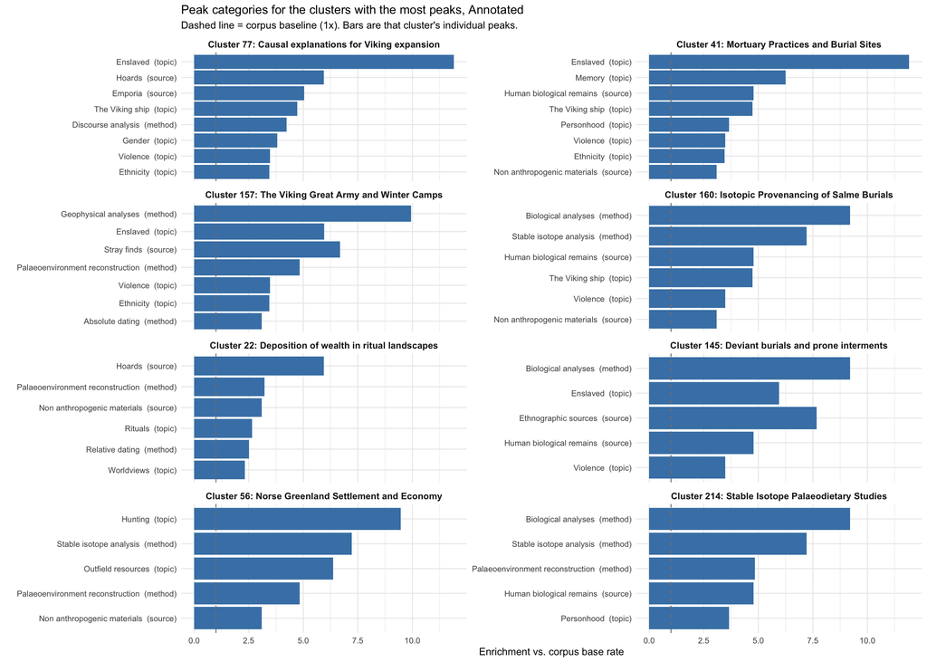

**Annotated, seed filtered**

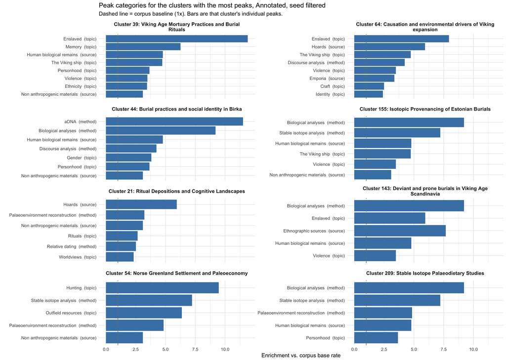

**Table, annotated**

The plot’s bars: every peak of the eight clusters with the most peaks, in the plot’s order.

| Cluster | label | category | type | works with it | annotated works | share (%) | corpus rate (%) | enrichment | Wilson 95% lower bound (%) |
| --- | --- | --- | --- | --- | --- | --- | --- | --- | --- |
| 77 | Causal explanations for Viking expansion | Enslaved | topic | 2 | 2 | 100.0 | 8.4 | 11.90 | 34.2 |
| 77 | Causal explanations for Viking expansion | Hoards | source | 2 | 2 | 100.0 | 16.8 | 5.94 | 34.2 |
| 77 | Causal explanations for Viking expansion | Emporia | source | 2 | 2 | 100.0 | 19.8 | 5.04 | 34.2 |
| 77 | Causal explanations for Viking expansion | The Viking ship | topic | 2 | 2 | 100.0 | 21.1 | 4.73 | 34.2 |
| 77 | Causal explanations for Viking expansion | Discourse analysis | method | 2 | 2 | 100.0 | 23.6 | 4.23 | 34.2 |
| 77 | Causal explanations for Viking expansion | Gender | topic | 2 | 2 | 100.0 | 26.3 | 3.80 | 34.2 |
| 77 | Causal explanations for Viking expansion | Violence | topic | 2 | 2 | 100.0 | 28.7 | 3.48 | 34.2 |
| 77 | Causal explanations for Viking expansion | Ethnicity | topic | 2 | 2 | 100.0 | 29.0 | 3.45 | 34.2 |
| 41 | Mortuary Practices and Burial Sites | Enslaved | topic | 2 | 2 | 100.0 | 8.4 | 11.90 | 34.2 |
| 41 | Mortuary Practices and Burial Sites | Memory | topic | 2 | 2 | 100.0 | 16.0 | 6.25 | 34.2 |
| 41 | Mortuary Practices and Burial Sites | Human biological remains | source | 2 | 2 | 100.0 | 20.9 | 4.78 | 34.2 |
| 41 | Mortuary Practices and Burial Sites | The Viking ship | topic | 2 | 2 | 100.0 | 21.1 | 4.73 | 34.2 |
| 41 | Mortuary Practices and Burial Sites | Personhood | topic | 2 | 2 | 100.0 | 27.4 | 3.65 | 34.2 |
| 41 | Mortuary Practices and Burial Sites | Violence | topic | 2 | 2 | 100.0 | 28.7 | 3.48 | 34.2 |
| 41 | Mortuary Practices and Burial Sites | Ethnicity | topic | 2 | 2 | 100.0 | 29.0 | 3.45 | 34.2 |
| 41 | Mortuary Practices and Burial Sites | Non anthropogenic materials | source | 2 | 2 | 100.0 | 32.3 | 3.09 | 34.2 |
| 157 | The Viking Great Army and Winter Camps | Geophysical analyses | method | 2 | 2 | 100.0 | 10.1 | 9.95 | 34.2 |
| 157 | The Viking Great Army and Winter Camps | Stray finds | source | 2 | 2 | 100.0 | 14.9 | 6.69 | 34.2 |
| 157 | The Viking Great Army and Winter Camps | Enslaved | topic | 1 | 2 | 50.0 | 8.4 | 5.95 | 9.5 |
| 157 | The Viking Great Army and Winter Camps | Palaeoenvironment reconstruction | method | 2 | 2 | 100.0 | 20.7 | 4.84 | 34.2 |
| 157 | The Viking Great Army and Winter Camps | Violence | topic | 2 | 2 | 100.0 | 28.7 | 3.48 | 34.2 |
| 157 | The Viking Great Army and Winter Camps | Ethnicity | topic | 2 | 2 | 100.0 | 29.0 | 3.45 | 34.2 |
| 157 | The Viking Great Army and Winter Camps | Absolute dating | method | 2 | 2 | 100.0 | 32.3 | 3.09 | 34.2 |
| 160 | Isotopic Provenancing of Salme Burials | Biological analyses | method | 2 | 2 | 100.0 | 10.9 | 9.20 | 34.2 |
| 160 | Isotopic Provenancing of Salme Burials | Stable isotope analysis | method | 2 | 2 | 100.0 | 13.9 | 7.22 | 34.2 |
| 160 | Isotopic Provenancing of Salme Burials | Human biological remains | source | 2 | 2 | 100.0 | 20.9 | 4.78 | 34.2 |
| 160 | Isotopic Provenancing of Salme Burials | The Viking ship | topic | 2 | 2 | 100.0 | 21.1 | 4.73 | 34.2 |
| 160 | Isotopic Provenancing of Salme Burials | Violence | topic | 2 | 2 | 100.0 | 28.7 | 3.48 | 34.2 |
| 160 | Isotopic Provenancing of Salme Burials | Non anthropogenic materials | source | 2 | 2 | 100.0 | 32.3 | 3.09 | 34.2 |
| 22 | Deposition of wealth in ritual landscapes | Hoards | source | 3 | 3 | 100.0 | 16.8 | 5.94 | 43.9 |
| 22 | Deposition of wealth in ritual landscapes | Palaeoenvironment reconstruction | method | 2 | 3 | 66.7 | 20.7 | 3.23 | 20.8 |
| 22 | Deposition of wealth in ritual landscapes | Non anthropogenic materials | source | 3 | 3 | 100.0 | 32.3 | 3.09 | 43.9 |
| 22 | Deposition of wealth in ritual landscapes | Rituals | topic | 3 | 3 | 100.0 | 37.7 | 2.65 | 43.9 |
| 22 | Deposition of wealth in ritual landscapes | Relative dating | method | 3 | 3 | 100.0 | 39.7 | 2.52 | 43.9 |
| 22 | Deposition of wealth in ritual landscapes | Worldviews | topic | 3 | 3 | 100.0 | 43.1 | 2.32 | 43.9 |
| 145 | Deviant burials and prone interments | Biological analyses | method | 2 | 2 | 100.0 | 10.9 | 9.20 | 34.2 |
| 145 | Deviant burials and prone interments | Ethnographic sources | source | 1 | 2 | 50.0 | 6.5 | 7.67 | 9.5 |
| 145 | Deviant burials and prone interments | Enslaved | topic | 1 | 2 | 50.0 | 8.4 | 5.95 | 9.5 |
| 145 | Deviant burials and prone interments | Human biological remains | source | 2 | 2 | 100.0 | 20.9 | 4.78 | 34.2 |
| 145 | Deviant burials and prone interments | Violence | topic | 2 | 2 | 100.0 | 28.7 | 3.48 | 34.2 |
| 56 | Norse Greenland Settlement and Economy | Hunting | topic | 2 | 2 | 100.0 | 10.6 | 9.46 | 34.2 |
| 56 | Norse Greenland Settlement and Economy | Stable isotope analysis | method | 2 | 2 | 100.0 | 13.9 | 7.22 | 34.2 |
| 56 | Norse Greenland Settlement and Economy | Outfield resources | topic | 2 | 2 | 100.0 | 15.7 | 6.36 | 34.2 |
| 56 | Norse Greenland Settlement and Economy | Palaeoenvironment reconstruction | method | 2 | 2 | 100.0 | 20.7 | 4.84 | 34.2 |
| 56 | Norse Greenland Settlement and Economy | Non anthropogenic materials | source | 2 | 2 | 100.0 | 32.3 | 3.09 | 34.2 |
| 214 | Stable Isotope Palaeodietary Studies | Biological analyses | method | 2 | 2 | 100.0 | 10.9 | 9.20 | 34.2 |
| 214 | Stable Isotope Palaeodietary Studies | Stable isotope analysis | method | 2 | 2 | 100.0 | 13.9 | 7.22 | 34.2 |
| 214 | Stable Isotope Palaeodietary Studies | Palaeoenvironment reconstruction | method | 2 | 2 | 100.0 | 20.7 | 4.84 | 34.2 |
| 214 | Stable Isotope Palaeodietary Studies | Human biological remains | source | 2 | 2 | 100.0 | 20.9 | 4.78 | 34.2 |
| 214 | Stable Isotope Palaeodietary Studies | Personhood | topic | 2 | 2 | 100.0 | 27.4 | 3.65 | 34.2 |

**Table, seed filtered**

Same columns, for the seed-filtered run.

| Cluster | label | category | type | works with it | annotated works | share (%) | corpus rate (%) | enrichment | Wilson 95% lower bound (%) |
| --- | --- | --- | --- | --- | --- | --- | --- | --- | --- |
| 39 | Viking Age Mortuary Practices and Burial Rituals | Enslaved | topic | 2 | 2 | 100.0 | 8.4 | 11.90 | 34.2 |
| 39 | Viking Age Mortuary Practices and Burial Rituals | Memory | topic | 2 | 2 | 100.0 | 16.0 | 6.25 | 34.2 |
| 39 | Viking Age Mortuary Practices and Burial Rituals | Human biological remains | source | 2 | 2 | 100.0 | 20.9 | 4.78 | 34.2 |
| 39 | Viking Age Mortuary Practices and Burial Rituals | The Viking ship | topic | 2 | 2 | 100.0 | 21.1 | 4.73 | 34.2 |
| 39 | Viking Age Mortuary Practices and Burial Rituals | Personhood | topic | 2 | 2 | 100.0 | 27.4 | 3.65 | 34.2 |
| 39 | Viking Age Mortuary Practices and Burial Rituals | Violence | topic | 2 | 2 | 100.0 | 28.7 | 3.48 | 34.2 |
| 39 | Viking Age Mortuary Practices and Burial Rituals | Ethnicity | topic | 2 | 2 | 100.0 | 29.0 | 3.45 | 34.2 |
| 39 | Viking Age Mortuary Practices and Burial Rituals | Non anthropogenic materials | source | 2 | 2 | 100.0 | 32.3 | 3.09 | 34.2 |
| 64 | Causation and environmental drivers of Viking expansion | Enslaved | topic | 2 | 3 | 66.7 | 8.4 | 7.94 | 20.8 |
| 64 | Causation and environmental drivers of Viking expansion | Hoards | source | 3 | 3 | 100.0 | 16.8 | 5.94 | 43.9 |
| 64 | Causation and environmental drivers of Viking expansion | The Viking ship | topic | 3 | 3 | 100.0 | 21.1 | 4.73 | 43.9 |
| 64 | Causation and environmental drivers of Viking expansion | Discourse analysis | method | 2 | 2 | 100.0 | 23.6 | 4.23 | 34.2 |
| 64 | Causation and environmental drivers of Viking expansion | Violence | topic | 3 | 3 | 100.0 | 28.7 | 3.48 | 43.9 |
| 64 | Causation and environmental drivers of Viking expansion | Emporia | source | 2 | 3 | 66.7 | 19.8 | 3.36 | 20.8 |
| 64 | Causation and environmental drivers of Viking expansion | Craft | topic | 3 | 3 | 100.0 | 40.1 | 2.49 | 43.9 |
| 64 | Causation and environmental drivers of Viking expansion | Identity | topic | 3 | 3 | 100.0 | 41.7 | 2.40 | 43.9 |
| 44 | Burial practices and social identity in Birka | aDNA | method | 1 | 2 | 50.0 | 4.3 | 11.50 | 9.5 |
| 44 | Burial practices and social identity in Birka | Biological analyses | method | 2 | 2 | 100.0 | 10.9 | 9.20 | 34.2 |
| 44 | Burial practices and social identity in Birka | Human biological remains | source | 2 | 2 | 100.0 | 20.9 | 4.78 | 34.2 |
| 44 | Burial practices and social identity in Birka | Discourse analysis | method | 2 | 2 | 100.0 | 23.6 | 4.23 | 34.2 |
| 44 | Burial practices and social identity in Birka | Gender | topic | 2 | 2 | 100.0 | 26.3 | 3.80 | 34.2 |
| 44 | Burial practices and social identity in Birka | Personhood | topic | 2 | 2 | 100.0 | 27.4 | 3.65 | 34.2 |
| 44 | Burial practices and social identity in Birka | Non anthropogenic materials | source | 2 | 2 | 100.0 | 32.3 | 3.09 | 34.2 |
| 155 | Isotopic Provenancing of Estonian Burials | Biological analyses | method | 2 | 2 | 100.0 | 10.9 | 9.20 | 34.2 |
| 155 | Isotopic Provenancing of Estonian Burials | Stable isotope analysis | method | 2 | 2 | 100.0 | 13.9 | 7.22 | 34.2 |
| 155 | Isotopic Provenancing of Estonian Burials | Human biological remains | source | 2 | 2 | 100.0 | 20.9 | 4.78 | 34.2 |
| 155 | Isotopic Provenancing of Estonian Burials | The Viking ship | topic | 2 | 2 | 100.0 | 21.1 | 4.73 | 34.2 |
| 155 | Isotopic Provenancing of Estonian Burials | Violence | topic | 2 | 2 | 100.0 | 28.7 | 3.48 | 34.2 |
| 155 | Isotopic Provenancing of Estonian Burials | Non anthropogenic materials | source | 2 | 2 | 100.0 | 32.3 | 3.09 | 34.2 |
| 21 | Ritual Depositions and Cognitive Landscapes | Hoards | source | 3 | 3 | 100.0 | 16.8 | 5.94 | 43.9 |
| 21 | Ritual Depositions and Cognitive Landscapes | Palaeoenvironment reconstruction | method | 2 | 3 | 66.7 | 20.7 | 3.23 | 20.8 |
| 21 | Ritual Depositions and Cognitive Landscapes | Non anthropogenic materials | source | 3 | 3 | 100.0 | 32.3 | 3.09 | 43.9 |
| 21 | Ritual Depositions and Cognitive Landscapes | Rituals | topic | 3 | 3 | 100.0 | 37.7 | 2.65 | 43.9 |
| 21 | Ritual Depositions and Cognitive Landscapes | Relative dating | method | 3 | 3 | 100.0 | 39.7 | 2.52 | 43.9 |
| 21 | Ritual Depositions and Cognitive Landscapes | Worldviews | topic | 3 | 3 | 100.0 | 43.1 | 2.32 | 43.9 |
| 143 | Deviant and prone burials in Viking Age Scandinavia | Biological analyses | method | 2 | 2 | 100.0 | 10.9 | 9.20 | 34.2 |
| 143 | Deviant and prone burials in Viking Age Scandinavia | Ethnographic sources | source | 1 | 2 | 50.0 | 6.5 | 7.67 | 9.5 |
| 143 | Deviant and prone burials in Viking Age Scandinavia | Enslaved | topic | 1 | 2 | 50.0 | 8.4 | 5.95 | 9.5 |
| 143 | Deviant and prone burials in Viking Age Scandinavia | Human biological remains | source | 2 | 2 | 100.0 | 20.9 | 4.78 | 34.2 |
| 143 | Deviant and prone burials in Viking Age Scandinavia | Violence | topic | 2 | 2 | 100.0 | 28.7 | 3.48 | 34.2 |
| 54 | Norse Greenland Settlement and Paleoeconomy | Hunting | topic | 2 | 2 | 100.0 | 10.6 | 9.46 | 34.2 |
| 54 | Norse Greenland Settlement and Paleoeconomy | Stable isotope analysis | method | 2 | 2 | 100.0 | 13.9 | 7.22 | 34.2 |
| 54 | Norse Greenland Settlement and Paleoeconomy | Outfield resources | topic | 2 | 2 | 100.0 | 15.7 | 6.36 | 34.2 |
| 54 | Norse Greenland Settlement and Paleoeconomy | Palaeoenvironment reconstruction | method | 2 | 2 | 100.0 | 20.7 | 4.84 | 34.2 |
| 54 | Norse Greenland Settlement and Paleoeconomy | Non anthropogenic materials | source | 2 | 2 | 100.0 | 32.3 | 3.09 | 34.2 |
| 209 | Stable Isotope Palaeodietary Studies | Biological analyses | method | 2 | 2 | 100.0 | 10.9 | 9.20 | 34.2 |
| 209 | Stable Isotope Palaeodietary Studies | Stable isotope analysis | method | 2 | 2 | 100.0 | 13.9 | 7.22 | 34.2 |
| 209 | Stable Isotope Palaeodietary Studies | Palaeoenvironment reconstruction | method | 2 | 2 | 100.0 | 20.7 | 4.84 | 34.2 |
| 209 | Stable Isotope Palaeodietary Studies | Human biological remains | source | 2 | 2 | 100.0 | 20.9 | 4.78 | 34.2 |
| 209 | Stable Isotope Palaeodietary Studies | Personhood | topic | 2 | 2 | 100.0 | 27.4 | 3.65 | 34.2 |

## Groups of clusters vs. topics, methods, and sources of evidence

Part 2 sorts the Girvan-Newman clusters into groups, using a consensus of eight community-detection variants run with five seeds each. This section repeats the comparison above one level up: each group’s annotated works are compared with the annotation of the whole corpus. Enrichment, peaks and heatmaps work as described above, with a group in place of a cluster. In Annotated there are 18 groups, of which 9 hold at least 10 annotated works (between 12 and 59 each); 9 of those 9 carry at least one peak (70 peaks in all), and the strongest is Stable isotope analysis in Group 7 at 5.9x. In Annotated, seed filtered there are 13 groups, of which 8 hold at least 10 annotated works (between 17 and 61 each); 8 of those 8 carry at least one peak (64 peaks in all), and the strongest is Outfield resources in Group 8 at 5.1x. Groups with fewer than 10 annotated works are listed in the first table but left out of the peaks and heatmaps. Each remaining group holds a few dozen annotated works at most, so only large gaps register as peaks. Each is compared on 42 categories, and about one peak per group could arise by chance at this bound. The uncoded majority of each group may tell a different story.

### What each group stands out for

Every group of two or more clusters, with its number of clusters, its papers, the annotated works among them and the categories it carries furthest above the corpus rate.

**Annotated**

| Group | Clusters | Papers | Annotated papers | Peaks | Strongest peaks (enrichment, annotated papers with it of those coded) |
| --- | --- | --- | --- | --- | --- |
| 1. Archaeological Excavation Standards and Stratigraphy | 53 | 1,948 | 59 | 7 | Emporia (3.4x, 40 of 59); Geochemical analyses (3x, 11 of 59); Craft (1.6x, 40 of 59) |
| 2. Runic Inscriptions and Epigraphy | 63 | 1,720 | 52 | 10 | Memory (3.1x, 25 of 52); Personhood (2.3x, 34 of 52); Ethnographic sources (2x, 7 of 51) |
| 3. Political power and ritual landscapes | 50 | 1,565 | 48 | 6 | Geophysical analyses (2.7x, 13 of 48); Stray finds (1.7x, 13 of 48); Absolute dating (1.7x, 26 of 48) |
| 4. Causal explanations for Viking expansion | 59 | 1,468 | 47 | 9 | Ethnicity (2.4x, 33 of 47); Violence (2x, 29 of 47); Diaspora (2x, 46 of 47) |
| 5. Social-ecological systems in medieval North Atlantic | 80 | 1,333 | 30 | 8 | Hunting (3.7x, 12 of 30); Palaeoenvironment reconstruction (2.6x, 16 of 30); Outfield resources (2.5x, 12 of 30) |
| 6. Archaeology and anthropology of childhood | 76 | 1,303 | 52 | 10 | Biological analyses (2.6x, 16 of 52); Enslaved (2.6x, 12 of 52); Gender (2.2x, 32 of 52) |
| 7. Genomic analysis of Viking Age fisheries | 59 | 1,060 | 30 | 9 | Stable isotope analysis (5.9x, 26 of 30); aDNA (4.3x, 6 of 30); Human biological remains (3.6x, 24 of 30) |
| 8. Ethnicity and inter-cultural contact in Sámi-Norse borderlands | 25 | 531 | 14 | 6 | Outfield resources (5.4x, 12 of 14); Hunting (4.6x, 7 of 14); Palaeoenvironment reconstruction (2.8x, 8 of 14) |
| 9. Cross-cultural contact and hybridity in the Baltic region | 11 | 362 | 12 | 5 | Heritage (3.7x, 3 of 12); Hoards (2.8x, 6 of 12); Ethnicity (2x, 7 of 12) |
| 10. Places of Assembly and Legal Sites | 8 | 309 | 7 | not tested | fewer than 10 annotated works |
| 11. Last millennium climate reconstruction methods | 133 | 274 | 2 | not tested | fewer than 10 annotated works |
| 12. Methodological approaches to stone iconography | 64 | 234 | 6 | not tested | fewer than 10 annotated works |
| 13. Archaeology of ship burials and dating | 26 | 161 | 3 | not tested | fewer than 10 annotated works |
| 14. Theoretical and Critical Approaches to Archaeology | 59 | 139 | 1 | not tested | fewer than 10 annotated works |
| 15. Trade and centers in the Eastern Baltic | 3 | 118 | 3 | not tested | fewer than 10 annotated works |
| 16. Urban Origins and Development in Southern Scandinavia | 19 | 99 | 1 | not tested | fewer than 10 annotated works |
| 17. AD 536 climate event and geomythology | 3 | 70 | 2 | not tested | fewer than 10 annotated works |
| 18. Community 482 | 2 | 2 | 0 | not tested | fewer than 10 annotated works |

**Annotated, seed filtered**

| Group | Clusters | Papers | Annotated papers | Peaks | Strongest peaks (enrichment, annotated papers with it of those coded) |
| --- | --- | --- | --- | --- | --- |
| 1. Archaeology of early urbanization in Southern Scandinavia | 52 | 2,096 | 61 | 6 | Geochemical analyses (3.5x, 12 of 61); Emporia (3.4x, 41 of 61); Craft (1.7x, 41 of 61) |
| 2. Archaeology and experimental reconstruction of Viking ships | 51 | 1,894 | 57 | 9 | Memory (2.7x, 25 of 57); Personhood (2.2x, 36 of 57); Hoards (2.1x, 20 of 56) |
| 3. Beowulf and Germanic Literary History | 46 | 1,545 | 46 | 6 | Geophysical analyses (2.8x, 13 of 46); Stray finds (1.8x, 13 of 46); Absolute dating (1.7x, 25 of 46) |
| 4. Causation and environmental drivers of Viking expansion | 67 | 1,387 | 45 | 9 | Ethnicity (2.6x, 33 of 45); Hoards (1.9x, 15 of 45); Violence (1.9x, 26 of 45) |
| 5. Construction of gender and masculinity in Viking Age Scandinavia | 49 | 1,303 | 47 | 10 | Biological analyses (3x, 16 of 47); Enslaved (2.4x, 10 of 47); Gender (2.4x, 31 of 47) |
| 6. Environmental history and climate impacts in medieval Iceland and Greenland | 44 | 1,276 | 29 | 8 | Hunting (3.8x, 12 of 29); Outfield resources (2.6x, 12 of 29); Ethnographic sources (2.4x, 5 of 29) |
| 7. Isotopic analysis for determining migration and diet in prehistory | 44 | 1,201 | 38 | 10 | Stable isotope analysis (4.9x, 27 of 38); aDNA (3.3x, 6 of 38); Human biological remains (2.9x, 24 of 38) |
| 8. Archaeological theory and the Anthropocene perspective | 58 | 698 | 17 | 6 | Outfield resources (5.1x, 14 of 17); Hunting (4.9x, 9 of 17); Ethnographic sources (3.3x, 4 of 17) |
| 9. Assemblies and Political Governance in Early Medieval Europe | 7 | 309 | 7 | not tested | fewer than 10 annotated works |
| 10. Baltic Region Cultural Contacts | 6 | 290 | 7 | not tested | fewer than 10 annotated works |
| 11. Methodologies for reconstructing past millennium climates | 116 | 274 | 2 | not tested | fewer than 10 annotated works |
| 12. Iconography and interpretation of Gotlandic picture stones | 49 | 261 | 7 | not tested | fewer than 10 annotated works |
| 13. Archaeology of Semigallia and Latvia | 3 | 116 | 3 | not tested | fewer than 10 annotated works |

### Groups by topic

**Annotated**

Works with a cluster assignment and any topic coded: 344

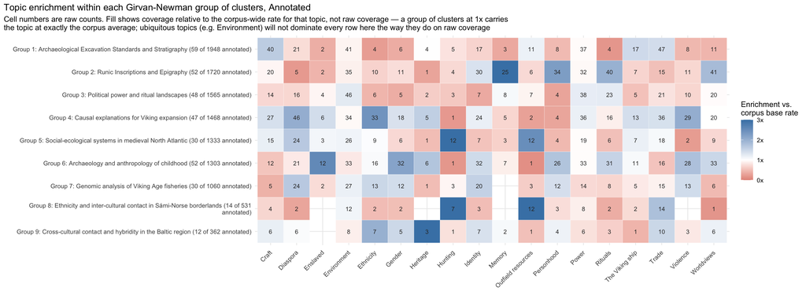

**Annotated, seed filtered**

Works with a cluster assignment and any topic coded: 340

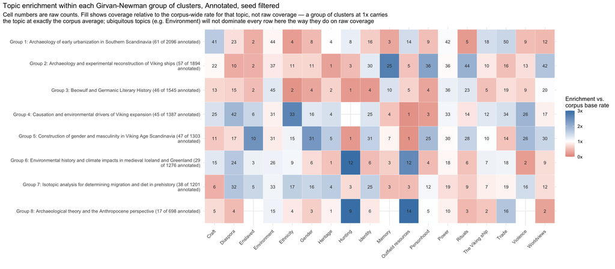

**Table, annotated**

The numbers behind the heatmap: one row per group and category, largest group first, strongest enrichment first within a group. A peak is a category whose Wilson 95% lower bound on the group’s share exceeds the corpus rate.

| Group | label | group size | annotated works | category | works with it | share (%) | corpus rate (%) | enrichment | Wilson 95% lower bound (%) | peak |
| --- | --- | --- | --- | --- | --- | --- | --- | --- | --- | --- |
| 1 | Archaeological Excavation Standards and Stratigraphy | 1948 | 59 | Craft | 40 | 67.8 | 41.6 | 1.63 | 55.1 | peak |
| 1 | Archaeological Excavation Standards and Stratigraphy | 1948 | 59 | The Viking ship | 17 | 28.8 | 19.8 | 1.46 | 18.8 |  |
| 1 | Archaeological Excavation Standards and Stratigraphy | 1948 | 59 | Trade | 47 | 79.7 | 55.8 | 1.43 | 67.7 | peak |
| 1 | Archaeological Excavation Standards and Stratigraphy | 1948 | 59 | Outfield resources | 11 | 18.6 | 16.0 | 1.17 | 10.7 |  |
| 1 | Archaeological Excavation Standards and Stratigraphy | 1948 | 59 | Heritage | 4 | 6.8 | 6.7 | 1.01 | 2.7 |  |
| 1 | Archaeological Excavation Standards and Stratigraphy | 1948 | 59 | Power | 37 | 62.7 | 64.8 | 0.97 | 50.0 |  |
| 1 | Archaeological Excavation Standards and Stratigraphy | 1948 | 59 | Environment | 41 | 69.5 | 76.2 | 0.91 | 56.9 |  |
| 1 | Archaeological Excavation Standards and Stratigraphy | 1948 | 59 | Hunting | 5 | 8.5 | 10.8 | 0.79 | 3.7 |  |
| 1 | Archaeological Excavation Standards and Stratigraphy | 1948 | 59 | Diaspora | 21 | 35.6 | 48.0 | 0.74 | 24.6 |  |
| 1 | Archaeological Excavation Standards and Stratigraphy | 1948 | 59 | Identity | 17 | 28.8 | 42.7 | 0.67 | 18.8 |  |
| 1 | Archaeological Excavation Standards and Stratigraphy | 1948 | 59 | Personhood | 8 | 13.6 | 28.8 | 0.47 | 7.0 |  |
| 1 | Archaeological Excavation Standards and Stratigraphy | 1948 | 59 | Violence | 8 | 13.6 | 30.2 | 0.45 | 7.0 |  |
| 1 | Archaeological Excavation Standards and Stratigraphy | 1948 | 59 | Worldviews | 11 | 18.6 | 42.7 | 0.44 | 10.7 |  |
| 1 | Archaeological Excavation Standards and Stratigraphy | 1948 | 59 | Enslaved | 2 | 3.4 | 9.0 | 0.38 | 0.9 |  |
| 1 | Archaeological Excavation Standards and Stratigraphy | 1948 | 59 | Gender | 6 | 10.2 | 28.2 | 0.36 | 4.7 |  |
| 1 | Archaeological Excavation Standards and Stratigraphy | 1948 | 59 | Memory | 3 | 5.1 | 15.4 | 0.33 | 1.7 |  |
| 1 | Archaeological Excavation Standards and Stratigraphy | 1948 | 59 | Ethnicity | 4 | 6.8 | 29.1 | 0.23 | 2.7 |  |
| 1 | Archaeological Excavation Standards and Stratigraphy | 1948 | 59 | Rituals | 4 | 6.8 | 38.7 | 0.18 | 2.7 |  |
| 2 | Runic Inscriptions and Epigraphy | 1720 | 52 | Memory | 25 | 48.1 | 15.4 | 3.12 | 35.1 | peak |
| 2 | Runic Inscriptions and Epigraphy | 1720 | 52 | Personhood | 34 | 65.4 | 28.8 | 2.27 | 51.8 | peak |
| 2 | Runic Inscriptions and Epigraphy | 1720 | 52 | Rituals | 40 | 76.9 | 38.7 | 1.99 | 63.9 | peak |
| 2 | Runic Inscriptions and Epigraphy | 1720 | 52 | Worldviews | 41 | 78.8 | 42.7 | 1.85 | 66.0 | peak |
| 2 | Runic Inscriptions and Epigraphy | 1720 | 52 | Identity | 30 | 57.7 | 42.7 | 1.35 | 44.2 | peak |
| 2 | Runic Inscriptions and Epigraphy | 1720 | 52 | Power | 32 | 61.5 | 64.8 | 0.95 | 48.0 |  |
| 2 | Runic Inscriptions and Epigraphy | 1720 | 52 | Craft | 20 | 38.5 | 41.6 | 0.93 | 26.5 |  |
| 2 | Runic Inscriptions and Epigraphy | 1720 | 52 | Environment | 35 | 67.3 | 76.2 | 0.88 | 53.8 |  |
| 2 | Runic Inscriptions and Epigraphy | 1720 | 52 | Gender | 11 | 21.2 | 28.2 | 0.75 | 12.2 |  |
| 2 | Runic Inscriptions and Epigraphy | 1720 | 52 | Outfield resources | 6 | 11.5 | 16.0 | 0.72 | 5.4 |  |
| 2 | Runic Inscriptions and Epigraphy | 1720 | 52 | Hunting | 4 | 7.7 | 10.8 | 0.72 | 3.0 |  |
| 2 | Runic Inscriptions and Epigraphy | 1720 | 52 | Violence | 11 | 21.2 | 30.2 | 0.70 | 12.2 |  |

[output cut: 126 more lines]

**Table, seed filtered**

Same columns, for the seed-filtered run.

| Group | label | group size | annotated works | category | works with it | share (%) | corpus rate (%) | enrichment | Wilson 95% lower bound (%) | peak |
| --- | --- | --- | --- | --- | --- | --- | --- | --- | --- | --- |
| 1 | Archaeology of early urbanization in Southern Scandinavia | 2096 | 61 | Craft | 41 | 67.2 | 40.6 | 1.66 | 54.7 | peak |
| 1 | Archaeology of early urbanization in Southern Scandinavia | 2096 | 61 | Trade | 50 | 82.0 | 54.7 | 1.50 | 70.5 | peak |
| 1 | Archaeology of early urbanization in Southern Scandinavia | 2096 | 61 | Outfield resources | 14 | 23.0 | 16.2 | 1.42 | 14.2 |  |
| 1 | Archaeology of early urbanization in Southern Scandinavia | 2096 | 61 | The Viking ship | 18 | 29.5 | 20.9 | 1.41 | 19.6 |  |
| 1 | Archaeology of early urbanization in Southern Scandinavia | 2096 | 61 | Hunting | 8 | 13.1 | 10.9 | 1.21 | 6.8 |  |
| 1 | Archaeology of early urbanization in Southern Scandinavia | 2096 | 61 | Power | 42 | 68.9 | 65.9 | 1.05 | 56.4 |  |
| 1 | Archaeology of early urbanization in Southern Scandinavia | 2096 | 61 | Heritage | 4 | 6.6 | 6.5 | 1.01 | 2.6 |  |
| 1 | Archaeology of early urbanization in Southern Scandinavia | 2096 | 61 | Environment | 44 | 72.1 | 77.1 | 0.94 | 59.8 |  |
| 1 | Archaeology of early urbanization in Southern Scandinavia | 2096 | 61 | Diaspora | 23 | 37.7 | 49.1 | 0.77 | 26.6 |  |
| 1 | Archaeology of early urbanization in Southern Scandinavia | 2096 | 61 | Identity | 16 | 26.2 | 42.1 | 0.62 | 16.8 |  |
| 1 | Archaeology of early urbanization in Southern Scandinavia | 2096 | 61 | Personhood | 9 | 14.8 | 28.8 | 0.51 | 8.0 |  |
| 1 | Archaeology of early urbanization in Southern Scandinavia | 2096 | 61 | Violence | 9 | 14.8 | 29.7 | 0.50 | 8.0 |  |
| 1 | Archaeology of early urbanization in Southern Scandinavia | 2096 | 61 | Gender | 8 | 13.1 | 27.9 | 0.47 | 6.8 |  |
| 1 | Archaeology of early urbanization in Southern Scandinavia | 2096 | 61 | Worldviews | 12 | 19.7 | 42.4 | 0.46 | 11.6 |  |
| 1 | Archaeology of early urbanization in Southern Scandinavia | 2096 | 61 | Enslaved | 2 | 3.3 | 8.8 | 0.37 | 0.9 |  |
| 1 | Archaeology of early urbanization in Southern Scandinavia | 2096 | 61 | Memory | 3 | 4.9 | 16.2 | 0.30 | 1.7 |  |
| 1 | Archaeology of early urbanization in Southern Scandinavia | 2096 | 61 | Ethnicity | 4 | 6.6 | 27.9 | 0.23 | 2.6 |  |
| 1 | Archaeology of early urbanization in Southern Scandinavia | 2096 | 61 | Rituals | 5 | 8.2 | 38.8 | 0.21 | 3.6 |  |
| 2 | Archaeology and experimental reconstruction of Viking ships | 1894 | 57 | Memory | 25 | 43.9 | 16.2 | 2.71 | 31.8 | peak |
| 2 | Archaeology and experimental reconstruction of Viking ships | 1894 | 57 | Personhood | 36 | 63.2 | 28.8 | 2.19 | 50.2 | peak |
| 2 | Archaeology and experimental reconstruction of Viking ships | 1894 | 57 | Rituals | 44 | 77.2 | 38.8 | 1.99 | 64.8 | peak |
| 2 | Archaeology and experimental reconstruction of Viking ships | 1894 | 57 | Worldviews | 42 | 73.7 | 42.4 | 1.74 | 61.0 | peak |
| 2 | Archaeology and experimental reconstruction of Viking ships | 1894 | 57 | Identity | 30 | 52.6 | 42.1 | 1.25 | 39.9 |  |
| 2 | Archaeology and experimental reconstruction of Viking ships | 1894 | 57 | Power | 36 | 63.2 | 65.9 | 0.96 | 50.2 |  |
| 2 | Archaeology and experimental reconstruction of Viking ships | 1894 | 57 | Craft | 22 | 38.6 | 40.6 | 0.95 | 27.1 |  |
| 2 | Archaeology and experimental reconstruction of Viking ships | 1894 | 57 | Environment | 37 | 64.9 | 77.1 | 0.84 | 51.9 |  |
| 2 | Archaeology and experimental reconstruction of Viking ships | 1894 | 57 | The Viking ship | 10 | 17.5 | 20.9 | 0.84 | 9.8 |  |
| 2 | Archaeology and experimental reconstruction of Viking ships | 1894 | 57 | Violence | 13 | 22.8 | 29.7 | 0.77 | 13.8 |  |
| 2 | Archaeology and experimental reconstruction of Viking ships | 1894 | 57 | Ethnicity | 11 | 19.3 | 27.9 | 0.69 | 11.1 |  |
| 2 | Archaeology and experimental reconstruction of Viking ships | 1894 | 57 | Gender | 11 | 19.3 | 27.9 | 0.69 | 11.1 |  |

[output cut: 110 more lines]

### Groups by method

**Annotated**

Works with a cluster assignment and any method coded: 343

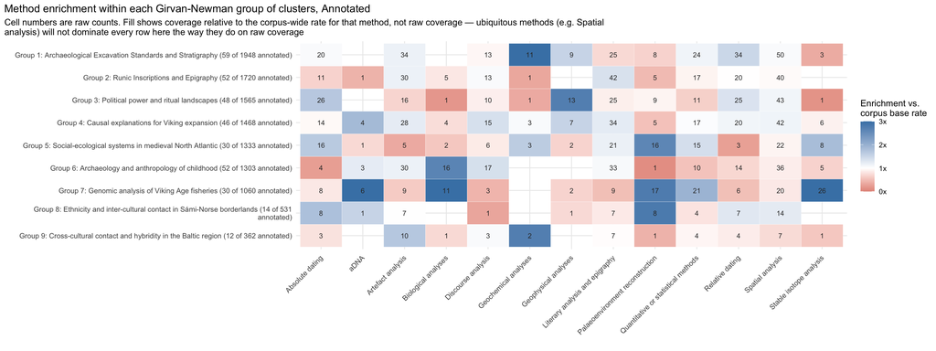

**Annotated, seed filtered**

Works with a cluster assignment and any method coded: 339

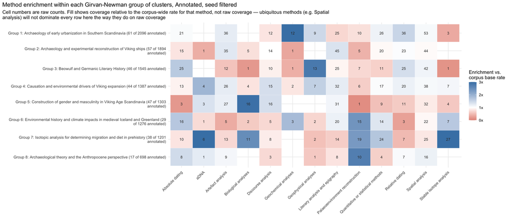

**Table, annotated**

The numbers behind the heatmap: one row per group and category, largest group first, strongest enrichment first within a group. A peak is a category whose Wilson 95% lower bound on the group’s share exceeds the corpus rate.

| Group | label | group size | annotated works | category | works with it | share (%) | corpus rate (%) | enrichment | Wilson 95% lower bound (%) | peak |
| --- | --- | --- | --- | --- | --- | --- | --- | --- | --- | --- |
| 1 | Archaeological Excavation Standards and Stratigraphy | 1948 | 59 | Geochemical analyses | 11 | 18.6 | 6.1 | 3.05 | 10.7 | peak |
| 1 | Archaeological Excavation Standards and Stratigraphy | 1948 | 59 | Geophysical analyses | 9 | 15.3 | 9.9 | 1.54 | 8.2 |  |
| 1 | Archaeological Excavation Standards and Stratigraphy | 1948 | 59 | Relative dating | 34 | 57.6 | 38.8 | 1.49 | 44.9 | peak |
| 1 | Archaeological Excavation Standards and Stratigraphy | 1948 | 59 | Artefact analysis | 34 | 57.6 | 49.3 | 1.17 | 44.9 |  |
| 1 | Archaeological Excavation Standards and Stratigraphy | 1948 | 59 | Quantitative or statistical methods | 24 | 40.7 | 35.9 | 1.13 | 29.1 |  |
| 1 | Archaeological Excavation Standards and Stratigraphy | 1948 | 59 | Spatial analysis | 50 | 84.7 | 79.9 | 1.06 | 73.5 |  |
| 1 | Archaeological Excavation Standards and Stratigraphy | 1948 | 59 | Absolute dating | 20 | 33.9 | 32.1 | 1.06 | 23.1 |  |
| 1 | Archaeological Excavation Standards and Stratigraphy | 1948 | 59 | Discourse analysis | 13 | 22.0 | 23.6 | 0.93 | 13.4 |  |
| 1 | Archaeological Excavation Standards and Stratigraphy | 1948 | 59 | Literary analysis and epigraphy | 25 | 42.4 | 59.2 | 0.72 | 30.6 |  |
| 1 | Archaeological Excavation Standards and Stratigraphy | 1948 | 59 | Palaeoenvironment reconstruction | 8 | 13.6 | 20.4 | 0.66 | 7.0 |  |
| 1 | Archaeological Excavation Standards and Stratigraphy | 1948 | 59 | Stable isotope analysis | 3 | 5.1 | 14.6 | 0.35 | 1.7 |  |
| 2 | Runic Inscriptions and Epigraphy | 1720 | 52 | Literary analysis and epigraphy | 42 | 80.8 | 59.2 | 1.36 | 68.1 | peak |
| 2 | Runic Inscriptions and Epigraphy | 1720 | 52 | Artefact analysis | 30 | 57.7 | 49.3 | 1.17 | 44.2 |  |
| 2 | Runic Inscriptions and Epigraphy | 1720 | 52 | Discourse analysis | 13 | 25.0 | 23.6 | 1.06 | 15.2 |  |
| 2 | Runic Inscriptions and Epigraphy | 1720 | 52 | Relative dating | 20 | 38.5 | 38.8 | 0.99 | 26.5 |  |
| 2 | Runic Inscriptions and Epigraphy | 1720 | 52 | Spatial analysis | 40 | 76.9 | 79.9 | 0.96 | 63.9 |  |
| 2 | Runic Inscriptions and Epigraphy | 1720 | 52 | Quantitative or statistical methods | 17 | 32.7 | 35.9 | 0.91 | 21.5 |  |
| 2 | Runic Inscriptions and Epigraphy | 1720 | 52 | Biological analyses | 5 | 9.6 | 11.7 | 0.82 | 4.2 |  |
| 2 | Runic Inscriptions and Epigraphy | 1720 | 52 | Absolute dating | 11 | 21.2 | 32.1 | 0.66 | 12.2 |  |
| 2 | Runic Inscriptions and Epigraphy | 1720 | 52 | Palaeoenvironment reconstruction | 5 | 9.6 | 20.4 | 0.47 | 4.2 |  |
| 2 | Runic Inscriptions and Epigraphy | 1720 | 52 | aDNA | 1 | 1.9 | 4.7 | 0.41 | 0.3 |  |
| 2 | Runic Inscriptions and Epigraphy | 1720 | 52 | Geochemical analyses | 1 | 1.9 | 6.1 | 0.31 | 0.3 |  |
| 3 | Political power and ritual landscapes | 1565 | 48 | Geophysical analyses | 13 | 27.1 | 9.9 | 2.73 | 16.6 | peak |
| 3 | Political power and ritual landscapes | 1565 | 48 | Absolute dating | 26 | 54.2 | 32.1 | 1.69 | 40.3 | peak |
| 3 | Political power and ritual landscapes | 1565 | 48 | Relative dating | 25 | 52.1 | 38.8 | 1.34 | 38.3 |  |
| 3 | Political power and ritual landscapes | 1565 | 48 | Spatial analysis | 43 | 89.6 | 79.9 | 1.12 | 77.8 |  |
| 3 | Political power and ritual landscapes | 1565 | 48 | Palaeoenvironment reconstruction | 9 | 18.8 | 20.4 | 0.92 | 10.2 |  |
| 3 | Political power and ritual landscapes | 1565 | 48 | Discourse analysis | 10 | 20.8 | 23.6 | 0.88 | 11.7 |  |
| 3 | Political power and ritual landscapes | 1565 | 48 | Literary analysis and epigraphy | 25 | 52.1 | 59.2 | 0.88 | 38.3 |  |
| 3 | Political power and ritual landscapes | 1565 | 48 | Artefact analysis | 16 | 33.3 | 49.3 | 0.68 | 21.7 |  |

[output cut: 74 more lines]

**Table, seed filtered**

Same columns, for the seed-filtered run.

| Group | label | group size | annotated works | category | works with it | share (%) | corpus rate (%) | enrichment | Wilson 95% lower bound (%) | peak |
| --- | --- | --- | --- | --- | --- | --- | --- | --- | --- | --- |
| 1 | Archaeology of early urbanization in Southern Scandinavia | 2096 | 61 | Geochemical analyses | 12 | 19.7 | 5.6 | 3.51 | 11.6 | peak |
| 1 | Archaeology of early urbanization in Southern Scandinavia | 2096 | 61 | Relative dating | 36 | 59.0 | 38.9 | 1.52 | 46.5 | peak |
| 1 | Archaeology of early urbanization in Southern Scandinavia | 2096 | 61 | Geophysical analyses | 9 | 14.8 | 10.0 | 1.47 | 8.0 |  |
| 1 | Archaeology of early urbanization in Southern Scandinavia | 2096 | 61 | Artefact analysis | 36 | 59.0 | 48.1 | 1.23 | 46.5 |  |
| 1 | Archaeology of early urbanization in Southern Scandinavia | 2096 | 61 | Quantitative or statistical methods | 26 | 42.6 | 36.9 | 1.16 | 31.0 |  |
| 1 | Archaeology of early urbanization in Southern Scandinavia | 2096 | 61 | Spatial analysis | 53 | 86.9 | 80.2 | 1.08 | 76.2 |  |
| 1 | Archaeology of early urbanization in Southern Scandinavia | 2096 | 61 | Absolute dating | 21 | 34.4 | 32.7 | 1.05 | 23.7 |  |
| 1 | Archaeology of early urbanization in Southern Scandinavia | 2096 | 61 | Discourse analysis | 12 | 19.7 | 24.5 | 0.80 | 11.6 |  |
| 1 | Archaeology of early urbanization in Southern Scandinavia | 2096 | 61 | Palaeoenvironment reconstruction | 10 | 16.4 | 21.5 | 0.76 | 9.2 |  |
| 1 | Archaeology of early urbanization in Southern Scandinavia | 2096 | 61 | Literary analysis and epigraphy | 25 | 41.0 | 59.0 | 0.69 | 29.5 |  |
| 1 | Archaeology of early urbanization in Southern Scandinavia | 2096 | 61 | Stable isotope analysis | 3 | 4.9 | 14.5 | 0.34 | 1.7 |  |
| 2 | Archaeology and experimental reconstruction of Viking ships | 1894 | 57 | Literary analysis and epigraphy | 45 | 78.9 | 59.0 | 1.34 | 66.7 | peak |
| 2 | Archaeology and experimental reconstruction of Viking ships | 1894 | 57 | Artefact analysis | 35 | 61.4 | 48.1 | 1.28 | 48.4 | peak |
| 2 | Archaeology and experimental reconstruction of Viking ships | 1894 | 57 | Relative dating | 23 | 40.4 | 38.9 | 1.04 | 28.6 |  |
| 2 | Archaeology and experimental reconstruction of Viking ships | 1894 | 57 | Discourse analysis | 14 | 24.6 | 24.5 | 1.00 | 15.2 |  |
| 2 | Archaeology and experimental reconstruction of Viking ships | 1894 | 57 | Spatial analysis | 44 | 77.2 | 80.2 | 0.96 | 64.8 |  |
| 2 | Archaeology and experimental reconstruction of Viking ships | 1894 | 57 | Quantitative or statistical methods | 20 | 35.1 | 36.9 | 0.95 | 24.0 |  |
| 2 | Archaeology and experimental reconstruction of Viking ships | 1894 | 57 | Absolute dating | 15 | 26.3 | 32.7 | 0.80 | 16.6 |  |
| 2 | Archaeology and experimental reconstruction of Viking ships | 1894 | 57 | Biological analyses | 5 | 8.8 | 11.5 | 0.76 | 3.8 |  |
| 2 | Archaeology and experimental reconstruction of Viking ships | 1894 | 57 | Palaeoenvironment reconstruction | 5 | 8.8 | 21.5 | 0.41 | 3.8 |  |
| 2 | Archaeology and experimental reconstruction of Viking ships | 1894 | 57 | aDNA | 1 | 1.8 | 4.7 | 0.37 | 0.3 |  |
| 2 | Archaeology and experimental reconstruction of Viking ships | 1894 | 57 | Geochemical analyses | 1 | 1.8 | 5.6 | 0.31 | 0.3 |  |
| 3 | Beowulf and Germanic Literary History | 1545 | 46 | Geophysical analyses | 13 | 28.3 | 10.0 | 2.82 | 17.3 | peak |
| 3 | Beowulf and Germanic Literary History | 1545 | 46 | Absolute dating | 25 | 54.3 | 32.7 | 1.66 | 40.2 | peak |
| 3 | Beowulf and Germanic Literary History | 1545 | 46 | Relative dating | 25 | 54.3 | 38.9 | 1.40 | 40.2 | peak |
| 3 | Beowulf and Germanic Literary History | 1545 | 46 | Spatial analysis | 42 | 91.3 | 80.2 | 1.14 | 79.7 |  |
| 3 | Beowulf and Germanic Literary History | 1545 | 46 | Literary analysis and epigraphy | 25 | 54.3 | 59.0 | 0.92 | 40.2 |  |
| 3 | Beowulf and Germanic Literary History | 1545 | 46 | Discourse analysis | 10 | 21.7 | 24.5 | 0.89 | 12.3 |  |
| 3 | Beowulf and Germanic Literary History | 1545 | 46 | Palaeoenvironment reconstruction | 7 | 15.2 | 21.5 | 0.71 | 7.6 |  |
| 3 | Beowulf and Germanic Literary History | 1545 | 46 | Quantitative or statistical methods | 11 | 23.9 | 36.9 | 0.65 | 13.9 |  |

[output cut: 63 more lines]

### Groups by source of evidence

**Annotated**

Works with a cluster assignment and any source coded: 343

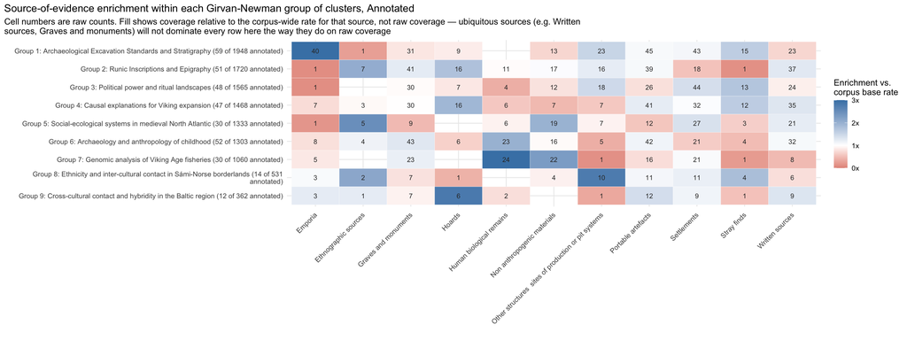

**Annotated, seed filtered**

Works with a cluster assignment and any source coded: 339

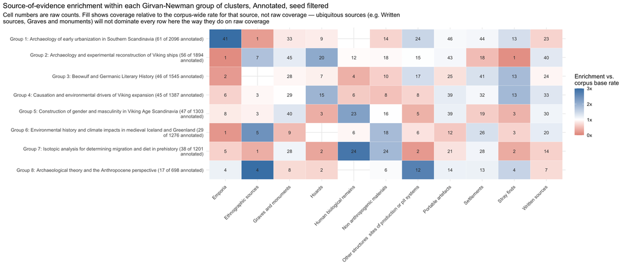

**Table, annotated**

The numbers behind the heatmap: one row per group and category, largest group first, strongest enrichment first within a group. A peak is a category whose Wilson 95% lower bound on the group’s share exceeds the corpus rate.

| Group | label | group size | annotated works | category | works with it | share (%) | corpus rate (%) | enrichment | Wilson 95% lower bound (%) | peak |
| --- | --- | --- | --- | --- | --- | --- | --- | --- | --- | --- |
| 1 | Archaeological Excavation Standards and Stratigraphy | 1948 | 59 | Emporia | 40 | 67.8 | 20.1 | 3.37 | 55.1 | peak |
| 1 | Archaeological Excavation Standards and Stratigraphy | 1948 | 59 | Stray finds | 15 | 25.4 | 15.7 | 1.61 | 16.1 | peak |
| 1 | Archaeological Excavation Standards and Stratigraphy | 1948 | 59 | Other structures sites of production or pit systems | 23 | 39.0 | 25.7 | 1.52 | 27.6 | peak |
| 1 | Archaeological Excavation Standards and Stratigraphy | 1948 | 59 | Settlements | 43 | 72.9 | 65.9 | 1.11 | 60.4 |  |
| 1 | Archaeological Excavation Standards and Stratigraphy | 1948 | 59 | Portable artefacts | 45 | 76.3 | 71.1 | 1.07 | 64.0 |  |
| 1 | Archaeological Excavation Standards and Stratigraphy | 1948 | 59 | Hoards | 9 | 15.3 | 17.8 | 0.86 | 8.2 |  |
| 1 | Archaeological Excavation Standards and Stratigraphy | 1948 | 59 | Graves and monuments | 31 | 52.5 | 64.4 | 0.82 | 40.0 |  |
| 1 | Archaeological Excavation Standards and Stratigraphy | 1948 | 59 | Non anthropogenic materials | 13 | 22.0 | 32.1 | 0.69 | 13.4 |  |
| 1 | Archaeological Excavation Standards and Stratigraphy | 1948 | 59 | Written sources | 23 | 39.0 | 56.9 | 0.69 | 27.6 |  |
| 1 | Archaeological Excavation Standards and Stratigraphy | 1948 | 59 | Ethnographic sources | 1 | 1.7 | 6.7 | 0.25 | 0.3 |  |
| 2 | Runic Inscriptions and Epigraphy | 1720 | 51 | Ethnographic sources | 7 | 13.7 | 6.7 | 2.05 | 6.8 | peak |
| 2 | Runic Inscriptions and Epigraphy | 1720 | 51 | Hoards | 16 | 31.4 | 17.8 | 1.76 | 20.3 | peak |
| 2 | Runic Inscriptions and Epigraphy | 1720 | 51 | Written sources | 37 | 72.5 | 56.9 | 1.28 | 59.1 | peak |
| 2 | Runic Inscriptions and Epigraphy | 1720 | 51 | Graves and monuments | 41 | 80.4 | 64.4 | 1.25 | 67.5 | peak |
| 2 | Runic Inscriptions and Epigraphy | 1720 | 51 | Other structures sites of production or pit systems | 16 | 31.4 | 25.7 | 1.22 | 20.3 |  |
| 2 | Runic Inscriptions and Epigraphy | 1720 | 51 | Portable artefacts | 39 | 76.5 | 71.1 | 1.07 | 63.2 |  |
| 2 | Runic Inscriptions and Epigraphy | 1720 | 51 | Non anthropogenic materials | 17 | 33.3 | 32.1 | 1.04 | 22.0 |  |
| 2 | Runic Inscriptions and Epigraphy | 1720 | 51 | Human biological remains | 11 | 21.6 | 22.2 | 0.97 | 12.5 |  |
| 2 | Runic Inscriptions and Epigraphy | 1720 | 51 | Settlements | 18 | 35.3 | 65.9 | 0.54 | 23.6 |  |
| 2 | Runic Inscriptions and Epigraphy | 1720 | 51 | Stray finds | 1 | 2.0 | 15.7 | 0.12 | 0.3 |  |
| 2 | Runic Inscriptions and Epigraphy | 1720 | 51 | Emporia | 1 | 2.0 | 20.1 | 0.10 | 0.3 |  |
| 3 | Political power and ritual landscapes | 1565 | 48 | Stray finds | 13 | 27.1 | 15.7 | 1.72 | 16.6 | peak |
| 3 | Political power and ritual landscapes | 1565 | 48 | Other structures sites of production or pit systems | 18 | 37.5 | 25.7 | 1.46 | 25.2 |  |
| 3 | Political power and ritual landscapes | 1565 | 48 | Settlements | 44 | 91.7 | 65.9 | 1.39 | 80.4 | peak |
| 3 | Political power and ritual landscapes | 1565 | 48 | Graves and monuments | 30 | 62.5 | 64.4 | 0.97 | 48.4 |  |
| 3 | Political power and ritual landscapes | 1565 | 48 | Written sources | 24 | 50.0 | 56.9 | 0.88 | 36.4 |  |
| 3 | Political power and ritual landscapes | 1565 | 48 | Hoards | 7 | 14.6 | 17.8 | 0.82 | 7.2 |  |
| 3 | Political power and ritual landscapes | 1565 | 48 | Non anthropogenic materials | 12 | 25.0 | 32.1 | 0.78 | 14.9 |  |
| 3 | Political power and ritual landscapes | 1565 | 48 | Portable artefacts | 26 | 54.2 | 71.1 | 0.76 | 40.3 |  |
| 3 | Political power and ritual landscapes | 1565 | 48 | Human biological remains | 4 | 8.3 | 22.2 | 0.38 | 3.3 |  |

[output cut: 62 more lines]

**Table, seed filtered**

Same columns, for the seed-filtered run.

| Group | label | group size | annotated works | category | works with it | share (%) | corpus rate (%) | enrichment | Wilson 95% lower bound (%) | peak |
| --- | --- | --- | --- | --- | --- | --- | --- | --- | --- | --- |
| 1 | Archaeology of early urbanization in Southern Scandinavia | 2096 | 61 | Emporia | 41 | 67.2 | 20.1 | 3.35 | 54.7 | peak |
| 1 | Archaeology of early urbanization in Southern Scandinavia | 2096 | 61 | Other structures sites of production or pit systems | 24 | 39.3 | 26.3 | 1.50 | 28.1 | peak |
| 1 | Archaeology of early urbanization in Southern Scandinavia | 2096 | 61 | Stray finds | 13 | 21.3 | 15.3 | 1.39 | 12.9 |  |
| 1 | Archaeology of early urbanization in Southern Scandinavia | 2096 | 61 | Settlements | 44 | 72.1 | 65.2 | 1.11 | 59.8 |  |
| 1 | Archaeology of early urbanization in Southern Scandinavia | 2096 | 61 | Portable artefacts | 46 | 75.4 | 70.5 | 1.07 | 63.3 |  |
| 1 | Archaeology of early urbanization in Southern Scandinavia | 2096 | 61 | Hoards | 9 | 14.8 | 17.1 | 0.86 | 8.0 |  |
| 1 | Archaeology of early urbanization in Southern Scandinavia | 2096 | 61 | Graves and monuments | 33 | 54.1 | 64.9 | 0.83 | 41.7 |  |
| 1 | Archaeology of early urbanization in Southern Scandinavia | 2096 | 61 | Non anthropogenic materials | 14 | 23.0 | 33.6 | 0.68 | 14.2 |  |
| 1 | Archaeology of early urbanization in Southern Scandinavia | 2096 | 61 | Written sources | 23 | 37.7 | 56.3 | 0.67 | 26.6 |  |
| 1 | Archaeology of early urbanization in Southern Scandinavia | 2096 | 61 | Ethnographic sources | 1 | 1.6 | 7.1 | 0.23 | 0.3 |  |
| 2 | Archaeology and experimental reconstruction of Viking ships | 1894 | 56 | Hoards | 20 | 35.7 | 17.1 | 2.09 | 24.5 | peak |
| 2 | Archaeology and experimental reconstruction of Viking ships | 1894 | 56 | Ethnographic sources | 7 | 12.5 | 7.1 | 1.77 | 6.2 |  |
| 2 | Archaeology and experimental reconstruction of Viking ships | 1894 | 56 | Written sources | 40 | 71.4 | 56.3 | 1.27 | 58.5 | peak |
| 2 | Archaeology and experimental reconstruction of Viking ships | 1894 | 56 | Graves and monuments | 45 | 80.4 | 64.9 | 1.24 | 68.2 | peak |
| 2 | Archaeology and experimental reconstruction of Viking ships | 1894 | 56 | Portable artefacts | 43 | 76.8 | 70.5 | 1.09 | 64.2 |  |
| 2 | Archaeology and experimental reconstruction of Viking ships | 1894 | 56 | Other structures sites of production or pit systems | 15 | 26.8 | 26.3 | 1.02 | 17.0 |  |
| 2 | Archaeology and experimental reconstruction of Viking ships | 1894 | 56 | Human biological remains | 12 | 21.4 | 22.1 | 0.97 | 12.7 |  |
| 2 | Archaeology and experimental reconstruction of Viking ships | 1894 | 56 | Non anthropogenic materials | 18 | 32.1 | 33.6 | 0.96 | 21.4 |  |
| 2 | Archaeology and experimental reconstruction of Viking ships | 1894 | 56 | Settlements | 18 | 32.1 | 65.2 | 0.49 | 21.4 |  |
| 2 | Archaeology and experimental reconstruction of Viking ships | 1894 | 56 | Stray finds | 1 | 1.8 | 15.3 | 0.12 | 0.3 |  |
| 2 | Archaeology and experimental reconstruction of Viking ships | 1894 | 56 | Emporia | 1 | 1.8 | 20.1 | 0.09 | 0.3 |  |
| 3 | Beowulf and Germanic Literary History | 1545 | 46 | Stray finds | 13 | 28.3 | 15.3 | 1.84 | 17.3 | peak |
| 3 | Beowulf and Germanic Literary History | 1545 | 46 | Other structures sites of production or pit systems | 17 | 37.0 | 26.3 | 1.41 | 24.5 |  |
| 3 | Beowulf and Germanic Literary History | 1545 | 46 | Settlements | 41 | 89.1 | 65.2 | 1.37 | 77.0 | peak |
| 3 | Beowulf and Germanic Literary History | 1545 | 46 | Graves and monuments | 28 | 60.9 | 64.9 | 0.94 | 46.5 |  |
| 3 | Beowulf and Germanic Literary History | 1545 | 46 | Written sources | 24 | 52.2 | 56.3 | 0.93 | 38.1 |  |
| 3 | Beowulf and Germanic Literary History | 1545 | 46 | Hoards | 7 | 15.2 | 17.1 | 0.89 | 7.6 |  |
| 3 | Beowulf and Germanic Literary History | 1545 | 46 | Portable artefacts | 25 | 54.3 | 70.5 | 0.77 | 40.2 |  |
| 3 | Beowulf and Germanic Literary History | 1545 | 46 | Non anthropogenic materials | 10 | 21.7 | 33.6 | 0.65 | 12.3 |  |
| 3 | Beowulf and Germanic Literary History | 1545 | 46 | Human biological remains | 4 | 8.7 | 22.1 | 0.39 | 3.4 |  |

[output cut: 54 more lines]

## Hubs of Shared references and Single hub clusters

A hub is a paper that cites other members of its cluster, and Part 2 sorts every cluster into a shape by how its hubs cite. This section sets the annotated hubs of Shared references clusters beside the annotated hubs of Single hub clusters, to see whether the two kinds of cluster draw on different topics, methods and sources of evidence. A hub carries a category when the annotation marks it as primary or secondary. Each point is the share of a group’s hubs that carry a category, with its Wilson 95% interval. The difference between the two shares has an interval built from the two Wilson intervals (Newcombe’s method), and a category counts as different when that interval excludes zero. The intervals are not adjusted for the number of categories compared, and the Shared references group is small.

### Topics, methods and sources of evidence

**Annotated**

The comparison covers 53 annotated hubs in Shared references clusters and 297 in Single hub clusters. 9 of 42 categories differ: Graves and monuments (+24 points), Worldviews (+20 points), Trade (-18 points), Identity (+17 points), Rituals (+17 points), Personhood (+16 points), Violence (+15 points), Human biological remains (+13 points), Enslaved (+10 points).

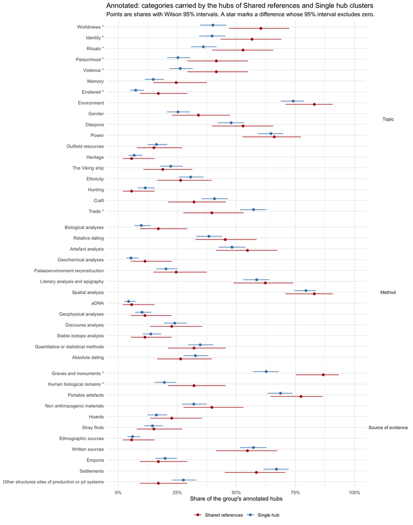

**Annotated, seed filtered**

The comparison covers 52 annotated hubs in Shared references clusters and 272 in Single hub clusters. 6 of 42 categories differ: Worldviews (+21 points), Graves and monuments (+18 points), Trade (-18 points), Rituals (+16 points), Personhood (+14 points), Hunting (-12 points).

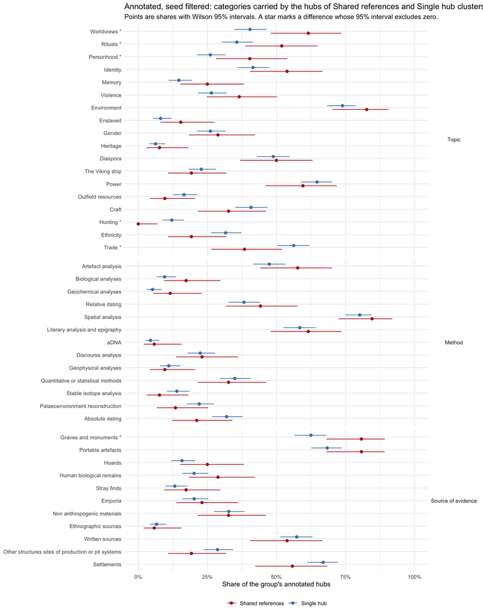

**Table, annotated**

The numbers behind the plot: one row per category, topics first, then methods, then sources of evidence, and within each kind the category the Shared references hubs carry most above the Single hub hubs first. The columns headed “Hubs” count the hubs that carry the category.

| Kind | Category | Hubs, Shared references | Share (%), Shared references | Interval (%), Shared references | Hubs, Single hub | Share (%), Single hub | Interval (%), Single hub | Difference (points) | Difference interval (points) | Interval excludes zero |
| --- | --- | --- | --- | --- | --- | --- | --- | --- | --- | --- |
| Topic | Worldviews | 32 | 60.4 | 46.9 to 72.4 | 119 | 40.1 | 34.7 to 45.7 | 20.3 | 5.7 to 33.5 | yes |
| Topic | Identity | 30 | 56.6 | 43.3 to 69 | 118 | 39.7 | 34.3 to 45.4 | 16.9 | 2.4 to 30.4 | yes |
| Topic | Rituals | 28 | 52.8 | 39.7 to 65.6 | 107 | 36.0 | 30.8 to 41.6 | 16.8 | 2.5 to 30.6 | yes |
| Topic | Personhood | 22 | 41.5 | 29.3 to 54.9 | 75 | 25.3 | 20.6 to 30.5 | 16.3 | 2.9 to 30.4 | yes |
| Topic | Violence | 22 | 41.5 | 29.3 to 54.9 | 78 | 26.3 | 21.6 to 31.5 | 15.2 | 1.9 to 29.4 | yes |
| Topic | Memory | 13 | 24.5 | 14.9 to 37.6 | 44 | 14.8 | 11.2 to 19.3 | 9.7 | -0.9 to 23.2 | no |
| Topic | Enslaved | 9 | 17.0 | 9.2 to 29.2 | 22 | 7.4 | 4.9 to 11 | 9.6 | 1 to 22.1 | yes |
| Topic | Environment | 44 | 83.0 | 70.8 to 90.8 | 220 | 74.1 | 68.8 to 78.7 | 8.9 | -4.2 to 18.3 | no |
| Topic | Gender | 18 | 34.0 | 22.7 to 47.4 | 75 | 25.3 | 20.6 to 30.5 | 8.7 | -3.7 to 22.9 | no |
| Topic | Diaspora | 28 | 52.8 | 39.7 to 65.6 | 142 | 47.8 | 42.2 to 53.5 | 5.0 | -9.3 to 19 | no |
| Topic | Power | 35 | 66.0 | 52.6 to 77.3 | 192 | 64.6 | 59.1 to 69.9 | 1.4 | -13 to 14 | no |
| Topic | Outfield resources | 8 | 15.1 | 7.9 to 27.1 | 48 | 16.2 | 12.4 to 20.8 | -1.1 | -9.7 to 11.5 | no |
| Topic | Heritage | 3 | 5.7 | 1.9 to 15.4 | 20 | 6.7 | 4.4 to 10.2 | -1.1 | -6.1 to 8.9 | no |
| Topic | The Viking ship | 10 | 18.9 | 10.6 to 31.4 | 66 | 22.2 | 17.9 to 27.3 | -3.4 | -13.1 to 9.9 | no |
| Topic | Ethnicity | 14 | 26.4 | 16.4 to 39.6 | 91 | 30.6 | 25.7 to 36.1 | -4.2 | -15.6 to 9.8 | no |
| Topic | Hunting | 3 | 5.7 | 1.9 to 15.4 | 34 | 11.4 | 8.3 to 15.6 | -5.8 | -11.3 to 4.4 | no |
| Topic | Craft | 17 | 32.1 | 21.1 to 45.5 | 121 | 40.7 | 35.3 to 46.4 | -8.7 | -21 to 5.8 | no |
| Topic | Trade | 21 | 39.6 | 27.6 to 53.1 | 170 | 57.2 | 51.6 to 62.7 | -17.6 | -30.8 to -3 | yes |
| Method | Biological analyses | 9 | 17.0 | 9.2 to 29.2 | 29 | 9.8 | 6.9 to 13.7 | 7.2 | -1.5 to 19.8 | no |
| Method | Relative dating | 24 | 45.3 | 32.7 to 58.5 | 114 | 38.4 | 33 to 44 | 6.9 | -6.9 to 21.2 | no |
| Method | Artefact analysis | 29 | 54.7 | 41.5 to 67.3 | 143 | 48.1 | 42.5 to 53.8 | 6.6 | -7.9 to 20.4 | no |
| Method | Geochemical analyses | 6 | 11.3 | 5.3 to 22.6 | 16 | 5.4 | 3.3 to 8.6 | 5.9 | -0.9 to 17.4 | no |
| Method | Palaeoenvironment reconstruction | 13 | 24.5 | 14.9 to 37.6 | 60 | 20.2 | 16 to 25.1 | 4.3 | -6.5 to 18 | no |
| Method | Literary analysis and epigraphy | 33 | 62.3 | 48.8 to 74.1 | 174 | 58.6 | 52.9 to 64 | 3.7 | -10.8 to 16.8 | no |
| Method | Spatial analysis | 44 | 83.0 | 70.8 to 90.8 | 236 | 79.5 | 74.5 to 83.7 | 3.6 | -9.4 to 12.8 | no |
| Method | aDNA | 3 | 5.7 | 1.9 to 15.4 | 13 | 4.4 | 2.6 to 7.3 | 1.3 | -3.5 to 11.2 | no |
| Method | Geophysical analyses | 6 | 11.3 | 5.3 to 22.6 | 30 | 10.1 | 7.2 to 14.1 | 1.2 | -6 to 12.9 | no |
| Method | Discourse analysis | 12 | 22.6 | 13.5 to 35.5 | 71 | 23.9 | 19.4 to 29.1 | -1.3 | -11.8 to 12.4 | no |
| Method | Stable isotope analysis | 6 | 11.3 | 5.3 to 22.6 | 41 | 13.8 | 10.3 to 18.2 | -2.5 | -9.9 to 9.3 | no |
| Method | Quantitative or statistical methods | 17 | 32.1 | 21.1 to 45.5 | 103 | 34.7 | 29.5 to 40.3 | -2.6 | -14.9 to 11.8 | no |
| Method | Absolute dating | 14 | 26.4 | 16.4 to 39.6 | 97 | 32.7 | 27.6 to 38.2 | -6.2 | -17.7 to 7.9 | no |
| Source of evidence | Graves and monuments | 46 | 86.8 | 75.2 to 93.5 | 186 | 62.6 | 57 to 67.9 | 24.2 | 11.4 to 32.9 | yes |
| Source of evidence | Human biological remains | 17 | 32.1 | 21.1 to 45.5 | 58 | 19.5 | 15.4 to 24.4 | 12.5 | 0.5 to 26.6 | yes |
| Source of evidence | Portable artefacts | 41 | 77.4 | 64.5 to 86.5 | 204 | 68.7 | 63.2 to 73.7 | 8.7 | -5.2 to 19.4 | no |
| Source of evidence | Non anthropogenic materials | 21 | 39.6 | 27.6 to 53.1 | 95 | 32.0 | 26.9 to 37.5 | 7.6 | -5.6 to 22 | no |
| Source of evidence | Hoards | 12 | 22.6 | 13.5 to 35.5 | 48 | 16.2 | 12.4 to 20.8 | 6.5 | -3.8 to 19.9 | no |
| Source of evidence | Stray finds | 8 | 15.1 | 7.9 to 27.1 | 43 | 14.5 | 10.9 to 18.9 | 0.6 | -7.9 to 13.1 | no |
| Source of evidence | Ethnographic sources | 3 | 5.7 | 1.9 to 15.4 | 18 | 6.1 | 3.9 to 9.4 | -0.4 | -5.4 to 9.6 | no |
| Source of evidence | Written sources | 29 | 54.7 | 41.5 to 67.3 | 170 | 57.2 | 51.6 to 62.7 | -2.5 | -16.9 to 11.3 | no |
| Source of evidence | Emporia | 9 | 17.0 | 9.2 to 29.2 | 59 | 19.9 | 15.7 to 24.8 | -2.9 | -12.1 to 10 | no |
| Source of evidence | Settlements | 31 | 58.5 | 45.1 to 70.7 | 199 | 67.0 | 61.5 to 72.1 | -8.5 | -22.8 to 4.9 | no |
| Source of evidence | Other structures sites of production or pit systems | 9 | 17.0 | 9.2 to 29.2 | 82 | 27.6 | 22.8 to 33 | -10.6 | -20.1 to 2.5 | no |

**Table, seed filtered**

Same columns, for the seed-filtered run.

| Kind | Category | Hubs, Shared references | Share (%), Shared references | Interval (%), Shared references | Hubs, Single hub | Share (%), Single hub | Interval (%), Single hub | Difference (points) | Difference interval (points) | Interval excludes zero |
| --- | --- | --- | --- | --- | --- | --- | --- | --- | --- | --- |
| Topic | Worldviews | 32 | 61.5 | 48 to 73.5 | 110 | 40.4 | 34.8 to 46.4 | 21.1 | 6.3 to 34.4 | yes |
| Topic | Rituals | 27 | 51.9 | 38.7 to 64.9 | 97 | 35.7 | 30.2 to 41.5 | 16.3 | 1.8 to 30.3 | yes |
| Topic | Personhood | 21 | 40.4 | 28.2 to 53.9 | 71 | 26.1 | 21.2 to 31.6 | 14.3 | 0.9 to 28.7 | yes |
| Topic | Identity | 28 | 53.8 | 40.5 to 66.7 | 113 | 41.5 | 35.8 to 47.5 | 12.3 | -2.3 to 26.3 | no |
| Topic | Memory | 13 | 25.0 | 15.2 to 38.2 | 40 | 14.7 | 11 to 19.4 | 10.3 | -0.5 to 24 | no |
| Topic | Violence | 19 | 36.5 | 24.8 to 50.1 | 72 | 26.5 | 21.6 to 32 | 10.1 | -2.9 to 24.5 | no |
| Topic | Environment | 43 | 82.7 | 70.3 to 90.6 | 201 | 73.9 | 68.4 to 78.8 | 8.8 | -4.5 to 18.5 | no |
| Topic | Enslaved | 8 | 15.4 | 8 to 27.5 | 22 | 8.1 | 5.4 to 11.9 | 7.3 | -1 to 19.7 | no |
| Topic | Gender | 15 | 28.8 | 18.3 to 42.3 | 71 | 26.1 | 21.2 to 31.6 | 2.7 | -9.1 to 17 | no |
| Topic | Heritage | 4 | 7.7 | 3 to 18.2 | 17 | 6.2 | 3.9 to 9.8 | 1.4 | -4.4 to 12.2 | no |
| Topic | Diaspora | 26 | 50.0 | 36.9 to 63.1 | 133 | 48.9 | 43 to 54.8 | 1.1 | -13.3 to 15.5 | no |
| Topic | The Viking ship | 10 | 19.2 | 10.8 to 31.9 | 62 | 22.8 | 18.2 to 28.1 | -3.6 | -13.5 to 9.9 | no |
| Topic | Power | 31 | 59.6 | 46.1 to 71.8 | 176 | 64.7 | 58.9 to 70.1 | -5.1 | -19.7 to 8.5 | no |
| Topic | Outfield resources | 5 | 9.6 | 4.2 to 20.6 | 45 | 16.5 | 12.6 to 21.4 | -6.9 | -14.2 to 4.8 | no |
| Topic | Craft | 17 | 32.7 | 21.5 to 46.2 | 111 | 40.8 | 35.1 to 46.7 | -8.1 | -20.8 to 6.6 | no |
| Topic | Hunting | 0 | 0.0 | 0 to 6.9 | 33 | 12.1 | 8.8 to 16.5 | -12.1 | -16.5 to -4.5 | yes |
| Topic | Ethnicity | 10 | 19.2 | 10.8 to 31.9 | 86 | 31.6 | 26.4 to 37.4 | -12.4 | -22.6 to 1.3 | no |
| Topic | Trade | 20 | 38.5 | 26.5 to 52 | 153 | 56.2 | 50.3 to 62 | -17.8 | -31.1 to -3 | yes |
| Method | Artefact analysis | 30 | 57.7 | 44.2 to 70.1 | 129 | 47.4 | 41.6 to 53.4 | 10.3 | -4.5 to 24 | no |
| Method | Biological analyses | 9 | 17.3 | 9.4 to 29.7 | 26 | 9.6 | 6.6 to 13.6 | 7.7 | -1.2 to 20.5 | no |
| Method | Geochemical analyses | 6 | 11.5 | 5.4 to 23 | 14 | 5.1 | 3.1 to 8.5 | 6.4 | -0.6 to 18 | no |
| Method | Relative dating | 23 | 44.2 | 31.6 to 57.7 | 104 | 38.2 | 32.7 to 44.1 | 6.0 | -8 to 20.5 | no |
| Method | Spatial analysis | 44 | 84.6 | 72.5 to 92 | 218 | 80.1 | 75 to 84.5 | 4.5 | -8.4 to 13.5 | no |
| Method | Literary analysis and epigraphy | 32 | 61.5 | 48 to 73.5 | 159 | 58.5 | 52.5 to 64.2 | 3.1 | -11.6 to 16.5 | no |
| Method | aDNA | 3 | 5.8 | 2 to 15.6 | 12 | 4.4 | 2.5 to 7.6 | 1.4 | -3.6 to 11.4 | no |
| Method | Discourse analysis | 12 | 23.1 | 13.7 to 36.1 | 61 | 22.4 | 17.9 to 27.7 | 0.7 | -10.1 to 14.5 | no |
| Method | Geophysical analyses | 5 | 9.6 | 4.2 to 20.6 | 30 | 11.0 | 7.8 to 15.3 | -1.4 | -8.3 to 10 | no |
| Method | Quantitative or statistical methods | 17 | 32.7 | 21.5 to 46.2 | 95 | 34.9 | 29.5 to 40.8 | -2.2 | -14.8 to 12.4 | no |
| Method | Stable isotope analysis | 4 | 7.7 | 3 to 18.2 | 38 | 14.0 | 10.4 to 18.6 | -6.3 | -12.8 to 4.8 | no |
| Method | Palaeoenvironment reconstruction | 7 | 13.5 | 6.7 to 25.3 | 60 | 22.1 | 17.5 to 27.4 | -8.6 | -17.2 to 4 | no |
| Method | Absolute dating | 11 | 21.2 | 12.2 to 34 | 87 | 32.0 | 26.7 to 37.7 | -10.8 | -21.4 to 3.1 | no |
| Source of evidence | Graves and monuments | 42 | 80.8 | 68.1 to 89.2 | 170 | 62.5 | 56.6 to 68 | 18.3 | 4.4 to 28.6 | yes |
| Source of evidence | Portable artefacts | 42 | 80.8 | 68.1 to 89.2 | 186 | 68.4 | 62.6 to 73.6 | 12.4 | -1.3 to 22.6 | no |
| Source of evidence | Hoards | 13 | 25.0 | 15.2 to 38.2 | 43 | 15.8 | 12 to 20.6 | 9.2 | -1.7 to 22.9 | no |
| Source of evidence | Human biological remains | 15 | 28.8 | 18.3 to 42.3 | 55 | 20.2 | 15.9 to 25.4 | 8.6 | -3.1 to 22.7 | no |
| Source of evidence | Stray finds | 9 | 17.3 | 9.4 to 29.7 | 36 | 13.2 | 9.7 to 17.8 | 4.1 | -5.1 to 17 | no |
| Source of evidence | Emporia | 12 | 23.1 | 13.7 to 36.1 | 55 | 20.2 | 15.9 to 25.4 | 2.9 | -7.8 to 16.6 | no |
| Source of evidence | Non anthropogenic materials | 17 | 32.7 | 21.5 to 46.2 | 89 | 32.7 | 27.4 to 38.5 | 0.0 | -12.6 to 14.5 | no |
| Source of evidence | Ethnographic sources | 3 | 5.8 | 2 to 15.6 | 18 | 6.6 | 4.2 to 10.2 | -0.8 | -6.1 to 9.3 | no |
| Source of evidence | Written sources | 28 | 53.8 | 40.5 to 66.7 | 156 | 57.4 | 51.4 to 63.1 | -3.5 | -18 to 10.6 | no |
| Source of evidence | Other structures sites of production or pit systems | 10 | 19.2 | 10.8 to 31.9 | 78 | 28.7 | 23.6 to 34.3 | -9.4 | -19.6 to 4.2 | no |
| Source of evidence | Settlements | 29 | 55.8 | 42.3 to 68.4 | 182 | 66.9 | 61.1 to 72.2 | -11.1 | -25.6 to 2.8 | no |

## Self-citation by topic, method and source of evidence

The Self-citation section of Part 2 counts the citations from each annotated paper to works that share an author with it. This section asks whether papers that carry a topic, a method or a source of evidence cite their own authors more or less than papers that do not. The first-author rate counts a citation when the citing paper’s first author wrote the cited work. The shared-author rate counts it when any author of the citing paper did, and it rises with the length of the author list, so the plot uses the first-author rate and the table carries both. Each paper is a unit in the resampling that gives the 95% intervals, which are not adjusted for the number of categories compared.

### Topics, methods and sources of evidence

**Plot**

Across the 369 annotated papers, 4.2% of citations go to a work by the citing paper’s first author and 7.2% to a work that shares an author with it. The first-author rate differs between papers that carry a category and papers that do not for 3 of 42 categories (aDNA -2.7, Hoards -1.3, Rituals -1.0), and the shared-author rate for 21 of 42 categories (Stable isotope analysis +8.9, Geochemical analyses +7.1, Palaeoenvironment reconstruction +6.0, Hunting +5.4, Rituals -4.2, and 16 more). Differences are in percentage points.

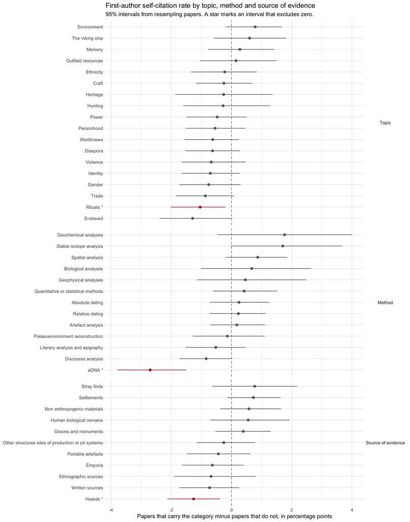

**Table**

The numbers behind the plot: one row per category, topics first, then methods, then sources of evidence, and within each kind the category with the largest first-author difference first. “Carrying” is the share of citations that are self-citations among the papers that carry the category, and “not carrying” is the same among all other annotated papers.

| Kind | Category | Papers carrying | First author, carrying (%) | First author, not carrying (%) | First author, difference (points) | First author, interval (points) | First author, interval excludes zero | Shared author, carrying (%) | Shared author, not carrying (%) | Shared author, difference (points) | Shared author, interval (points) | Shared author, interval excludes zero |
| --- | --- | --- | --- | --- | --- | --- | --- | --- | --- | --- | --- | --- |
| Topic | Environment | 279 | 4.4 | 3.6 | 0.8 | -0.2 to 1.7 | no | 7.8 | 5.7 | 2.0 | 0.2 to 3.7 | yes |
| Topic | The Viking ship | 78 | 4.7 | 4.1 | 0.6 | -0.6 to 1.8 | no | 9.5 | 6.6 | 3.0 | 0.3 to 5.9 | yes |
| Topic | Memory | 59 | 4.5 | 4.2 | 0.3 | -0.8 to 1.4 | no | 5.3 | 7.6 | -2.4 | -4 to -0.7 | yes |
| Topic | Outfield resources | 58 | 4.4 | 4.2 | 0.2 | -1.1 to 1.5 | no | 9.8 | 6.7 | 3.1 | 0.2 to 6.3 | yes |
| Topic | Ethnicity | 107 | 4.1 | 4.3 | -0.2 | -1.3 to 0.8 | no | 8.5 | 6.7 | 1.8 | -0.7 to 4.5 | no |
| Topic | Craft | 148 | 4.1 | 4.3 | -0.3 | -1.2 to 0.7 | no | 6.7 | 7.6 | -1.0 | -2.9 to 1.3 | no |
| Topic | Heritage | 24 | 4.0 | 4.2 | -0.3 | -1.9 to 1.4 | no | 5.4 | 7.4 | -2.0 | -4.2 to 0.1 | no |
| Topic | Hunting | 39 | 4.0 | 4.3 | -0.3 | -1.6 to 1.3 | no | 11.9 | 6.6 | 5.4 | 1.6 to 9.3 | yes |
| Topic | Power | 239 | 4.1 | 4.5 | -0.5 | -1.5 to 0.5 | no | 7.0 | 7.7 | -0.7 | -2.6 to 1.3 | no |
| Topic | Personhood | 101 | 3.8 | 4.4 | -0.5 | -1.5 to 0.5 | no | 5.6 | 7.9 | -2.3 | -3.9 to -0.6 | yes |
| Topic | Worldviews | 159 | 3.9 | 4.5 | -0.6 | -1.6 to 0.3 | no | 5.7 | 8.5 | -2.8 | -4.7 to -0.9 | yes |
| Topic | Diaspora | 179 | 3.9 | 4.5 | -0.6 | -1.5 to 0.3 | no | 7.6 | 6.9 | 0.7 | -1.3 to 2.6 | no |
| Topic | Violence | 106 | 3.8 | 4.4 | -0.7 | -1.7 to 0.5 | no | 5.5 | 8.0 | -2.5 | -4.3 to -0.7 | yes |
| Topic | Identity | 154 | 3.8 | 4.6 | -0.7 | -1.7 to 0.3 | no | 6.5 | 7.9 | -1.4 | -3.5 to 0.8 | no |
| Topic | Gender | 97 | 3.7 | 4.4 | -0.8 | -1.7 to 0.3 | no | 5.5 | 7.9 | -2.4 | -4.3 to -0.6 | yes |
| Topic | Trade | 199 | 3.8 | 4.7 | -0.9 | -1.8 to 0.1 | no | 7.4 | 7.1 | 0.2 | -1.6 to 2.1 | no |
| Topic | Rituals | 139 | 3.6 | 4.6 | -1.0 | -2 to -0.2 | yes | 4.8 | 8.9 | -4.2 | -5.9 to -2.6 | yes |
| Topic | Enslaved | 31 | 3.1 | 4.4 | -1.3 | -2.4 to 0 | no | 4.0 | 7.6 | -3.6 | -5.4 to -1.6 | yes |
| Method | Geochemical analyses | 22 | 5.9 | 4.1 | 1.8 | -0.5 to 4 | no | 13.9 | 6.8 | 7.1 | 0.7 to 14 | yes |
| Method | Stable isotope analysis | 51 | 5.7 | 4.0 | 1.7 | 0 to 3.7 | no | 14.8 | 5.8 | 8.9 | 5.4 to 13.1 | yes |
| Method | Spatial analysis | 292 | 4.4 | 3.5 | 0.9 | -0.2 to 1.9 | no | 7.0 | 8.1 | -1.1 | -4.7 to 1.7 | no |
| Method | Biological analyses | 40 | 4.8 | 4.2 | 0.7 | -1 to 2.6 | no | 7.6 | 7.2 | 0.3 | -2.3 to 3.6 | no |
| Method | Geophysical analyses | 37 | 4.6 | 4.2 | 0.5 | -1.2 to 2.5 | no | 9.7 | 7.0 | 2.7 | 0.1 to 5.6 | yes |
| Method | Quantitative or statistical methods | 128 | 4.5 | 4.1 | 0.4 | -0.6 to 1.5 | no | 8.2 | 6.8 | 1.4 | -0.6 to 3.3 | no |
| Method | Absolute dating | 119 | 4.4 | 4.2 | 0.3 | -0.7 to 1.3 | no | 8.5 | 6.7 | 1.8 | -0.3 to 4 | no |
| Method | Relative dating | 146 | 4.4 | 4.1 | 0.2 | -0.7 to 1.1 | no | 6.9 | 7.5 | -0.5 | -2.5 to 1.6 | no |
| Method | Artefact analysis | 180 | 4.3 | 4.1 | 0.2 | -0.7 to 1.1 | no | 6.5 | 8.0 | -1.5 | -3.5 to 0.6 | no |
| Method | Palaeoenvironment reconstruction | 76 | 4.1 | 4.3 | -0.1 | -1.3 to 1.1 | no | 12.0 | 5.9 | 6.0 | 3.4 to 8.7 | yes |
| Method | Literary analysis and epigraphy | 220 | 4.0 | 4.6 | -0.5 | -1.5 to 0.5 | no | 6.3 | 9.0 | -2.8 | -5.1 to -0.7 | yes |
| Method | Discourse analysis | 87 | 3.6 | 4.4 | -0.8 | -1.7 to 0 | no | 4.9 | 7.9 | -3.0 | -4.6 to -1.3 | yes |
| Method | aDNA | 16 | 1.6 | 4.4 | -2.7 | -3.8 to -1.5 | yes | 10.0 | 7.1 | 2.9 | -1.4 to 7.2 | no |
| Source of evidence | Stray finds | 55 | 4.9 | 4.1 | 0.8 | -0.6 to 2.2 | no | 9.3 | 6.9 | 2.4 | -1.1 to 6.8 | no |
| Source of evidence | Settlements | 241 | 4.5 | 3.8 | 0.7 | -0.1 to 1.6 | no | 8.1 | 5.6 | 2.5 | 0.8 to 4.1 | yes |
| Source of evidence | Non anthropogenic materials | 119 | 4.6 | 4.0 | 0.6 | -0.4 to 1.6 | no | 9.5 | 6.1 | 3.4 | 1.4 to 5.6 | yes |
| Source of evidence | Human biological remains | 77 | 4.7 | 4.1 | 0.6 | -0.7 to 1.9 | no | 8.7 | 6.8 | 1.9 | -0.4 to 4.3 | no |
| Source of evidence | Graves and monuments | 240 | 4.3 | 4.0 | 0.4 | -0.5 to 1.3 | no | 6.7 | 8.4 | -1.7 | -3.8 to 0.4 | no |
| Source of evidence | Other structures sites of production or pit systems | 98 | 4.0 | 4.3 | -0.3 | -1.2 to 0.8 | no | 6.7 | 7.4 | -0.7 | -2.6 to 1 | no |
| Source of evidence | Portable artefacts | 257 | 4.1 | 4.5 | -0.4 | -1.5 to 0.6 | no | 6.3 | 9.4 | -3.0 | -5.4 to -0.9 | yes |
| Source of evidence | Emporia | 73 | 3.7 | 4.4 | -0.6 | -1.6 to 0.4 | no | 7.0 | 7.3 | -0.3 | -3 to 3 | no |
| Source of evidence | Ethnographic sources | 24 | 3.6 | 4.3 | -0.7 | -1.9 to 0.8 | no | 5.1 | 7.4 | -2.3 | -4.4 to 0.4 | no |
| Source of evidence | Written sources | 210 | 3.9 | 4.7 | -0.7 | -1.7 to 0.2 | no | 6.5 | 8.4 | -1.9 | -4.1 to 0 | no |
| Source of evidence | Hoards | 62 | 3.2 | 4.4 | -1.3 | -2.1 to -0.4 | yes | 4.2 | 7.9 | -3.6 | -5.3 to -2.1 | yes |